# Data Wrangling and Statistical Programming Specialist

# City University of New York, New York City College of Technology Alumni (Graduate)

Email

[GitHub](https://github.com/LeSeanRoberts)

[LinkedIn](https://www.linkedin.com/in/le-sean-roberts)

# Analysis of the 2018-2019 New York City Hyperlocal Temperature Monitoring Dataset

## Introduction

The dataset analysed in this study consists of over 2 million rows of data. It offers a unique opportunity to apply advanced machine learning and statistical techniques to urban climate science. This research pursues three primary analytical objectives. First, we utilize Mini-Batch K-Means clustering to segment the city into distinct thermal profiles based on geographic coordinates and temperature, both at a global city-wide scale and within individual boroughs. Second, we investigate the relationship between the city’s geographic extremes by isolating the most northern, southern, eastern, and western sensors. Then, we compare Local Outlier Factor (LOF) and Histogram-based Outlier Score (HBOS) methods to detect sensor anomalies—identifying instances where specific street-level conditions deviate significantly from the expected borough-wide norms. Through Augmented Dickey-Fuller (ADF) tests and cointegration analysis, we examine whether these distant micro-climates move in a long-term statistical equilibrium despite their local variances. Through these methods, we aim to quantify the granularity of New York’s urban heat landscape and provide a data-driven foundation for future resiliency planning.

## Data Wrangling: A Special Case of Applying Feature Engineering, Data Analysis and Machine Learning Prematurely

In this pursuit, the implementation of data wrangling or data cleaning isn't a conventional experience for the novice. for temporal data with remote sensing technologies, often there's technological malfunctions leading to a considerate amount missing instances of measure thoroughout time. Due to the pursuits in this development being temporal and climate related, the common crude methods of either dropping rows with missing values, or applying the mean, or median are not practical. The simple act of dropping rows (instances) with missing values can result in (large) "time gaps" that distort temporal and spatial analysis. Taking the average when there are seasons in a climate isn't sensible; likewise with the median measure. Observed in this development is the peculiar case of applying a non-parametric, supervised learning classifier algorithm, known as **K-Nearest Neighbours**, which applies proximity to make classifications or predictions. KNN is applied to fill in missing values, where these values are placed appropriately as instances w.r.t. the hour or datetime for temperature readings via the Pandas framework or tools for dataframes.

### NYC Hyperlocal Temperature Monitoring Data Description

| Attribute | Description | API Field | Data Type |
| --- | --- | --- | --- |
| **Sensor.ID** | Unique identifier of sensor | `sensor_id` | Text |
| **AirTemp** | Average hourly air temperature (Fahrenheit) | `airtemp` | Number |
| **Day** | Date of recording | `day` | Timestamp |
| **Hour** | Hour of day (0-23) | `hour` | Number |
| **Latitude** | Latitude of sensor | `latitude` | Number |
| **Longitude** | Longitude of sensor | `longitude` | Number |
| **Year** | Year of data collection | `year` | Text |
| **Install.Type** | Type of mounting (street tree/street light) | `install_type` | Text |
| **Borough** | NYC Borough | `borough` | Text |
| **ntacode** | Neighborhood Tabulation Area code | `ntacode` | Text |

**Mathematical Representation of Average Temperature ($T_{avg}$):** $$T_{avg} = \frac{1}{n} \sum_{i=1}^{n} T_i$$

Data Assimilation:

```python
import numpy as np
import pandas as pd

nyc_hyper_local_temp = pd.read_csv('Hyperlocal_Temperature_Monitoring_20240308.csv')
nyc_hyper_local_temp.info()
```

```
<class 'pandas.core.frame.DataFrame'>
RangeIndex: 2097150 entries, 0 to 2097149
Data columns (total 10 columns):
 #   Column        Dtype
---  ------        -----
 0   Sensor.ID     object
 1   AirTemp       float64
 2   Day           object
 3   Hour          int64
 4   Latitude      float64
 5   Longitude     float64
 6   Year          int64
 7   Install.Type  object
 8   Borough       object
 9   ntacode       object
dtypes: float64(3), int64(2), object(5)
memory usage: 160.0+ MB
```

### Feature Engineering - Development of the Datetime Attribute

Developing a column called 'Datetime' by combining the 'Day' and 'Hour' columns. Such feature engineering concerns future time series analysis.

```python
# Creating a datetime column, to be placed after the 'Hour' column.

# Parse day
nyc_hyper_local_temp["Day"] = pd.to_datetime(nyc_hyper_local_temp["Day"], format="%m/%d/%Y")

# Combine normally
nyc_hyper_local_temp["Datetime"] = nyc_hyper_local_temp["Day"] + pd.to_timedelta(nyc_hyper_local_temp["Hour"], unit="h")

# place after Hour column
nyc_hyper_local_temp.insert(nyc_hyper_local_temp.columns.get_loc("Hour")+1,
                            "Datetime",
                            nyc_hyper_local_temp.pop("Datetime"))
```

```python
nyc_hyper_local_temp.info()
```

```
<class 'pandas.core.frame.DataFrame'>
RangeIndex: 2097150 entries, 0 to 2097149
Data columns (total 11 columns):
 #   Column        Dtype
---  ------        -----
 0   Sensor.ID     object
 1   AirTemp       float64
 2   Day           datetime64[ns]
 3   Hour          int64
 4   Datetime      datetime64[ns]
 5   Latitude      float64
 6   Longitude     float64
 7   Year          int64
 8   Install.Type  object
 9   Borough       object
 10  ntacode       object
dtypes: datetime64[ns](2), float64(3), int64(2), object(4)
memory usage: 176.0+ MB
```

```python
nyc_hyper_local_temp.head(5)
```

|  | Sensor.ID | AirTemp | Day | Hour | Datetime | Latitude | Longitude | Year | Install.Type | Borough | ntacode |
| --- | --- | --- | --- | --- | --- | --- | --- | --- | --- | --- | --- |
| 0 | Bk-BR_01 | 71.189000 | 2018-06-15 | 1 | 2018-06-15 01:00:00 | 40.666205 | -73.91691 | 2018 | Street Tree | Brooklyn | BK81 |
| 1 | Bk-BR_01 | 70.243333 | 2018-06-15 | 2 | 2018-06-15 02:00:00 | 40.666205 | -73.91691 | 2018 | Street Tree | Brooklyn | BK81 |
| 2 | Bk-BR_01 | 69.392667 | 2018-06-15 | 3 | 2018-06-15 03:00:00 | 40.666205 | -73.91691 | 2018 | Street Tree | Brooklyn | BK81 |
| 3 | Bk-BR_01 | 68.263167 | 2018-06-15 | 4 | 2018-06-15 04:00:00 | 40.666205 | -73.91691 | 2018 | Street Tree | Brooklyn | BK81 |
| 4 | Bk-BR_01 | 67.114000 | 2018-06-15 | 5 | 2018-06-15 05:00:00 | 40.666205 | -73.91691 | 2018 | Street Tree | Brooklyn | BK81 |

### The Commencement of Data Analysis for Missing Temperature Readings and Data Cleaning

Checking for missing values:

```python
nyc_hyper_local_temp.isna().sum()
```

```
Sensor.ID           0
AirTemp         11707
Day                 0
Hour                0
Datetime            0
Latitude            0
Longitude           0
Year                0
Install.Type        0
Borough             0
ntacode             0
dtype: int64
```

```python
nyc_hyper_local_temp.isnull().sum()
```

```
Sensor.ID           0
AirTemp         11707
Day                 0
Hour                0
Datetime            0
Latitude            0
Longitude           0
Year                0
Install.Type        0
Borough             0
ntacode             0
dtype: int64
```

Counting the missing reads per sensor:

```python
# Count missing AirTemp per sensor
missing_per_sensor = nyc_hyper_local_temp.groupby('Sensor.ID')['AirTemp'].apply(lambda x: x.isna().sum())
missing_per_sensor.sort_values(ascending=False)
```

```
Sensor.ID
Bk-EN_25    2948
Bk-EN_13    2948
Bk-EF_15    1838
Bk-EN_09    1812
Bk-RH_33     903
            ...
Bk-SH_16       0
Bk-SH_15       0
Bk-SH_13       0
Bk-SH_12       0
Q-JC_04        0
Name: AirTemp, Length: 423, dtype: int64
```

If a few sensors have disproportionately high missing counts → potential malfunction.

If missing values are spread roughly evenly → more likely random or environment-dependent.

**Key Features for distribution plot:**

1. Dynamic figure width: scales with the number of sensors.
2. Label skipping: for more than 50 sensors, only shows every 5th label to keep it readable.
3. Sorted bars: sensors with more missing values appear first, making trends easier to spot.

This approach works well for 200+ sensors without producing a crammed, unreadable plot.

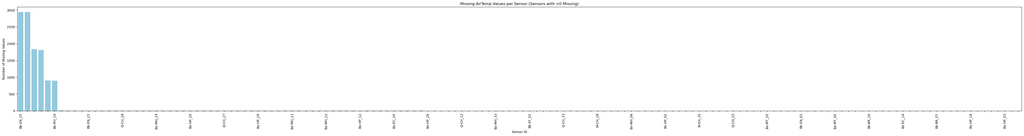

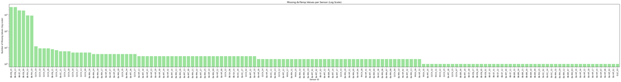

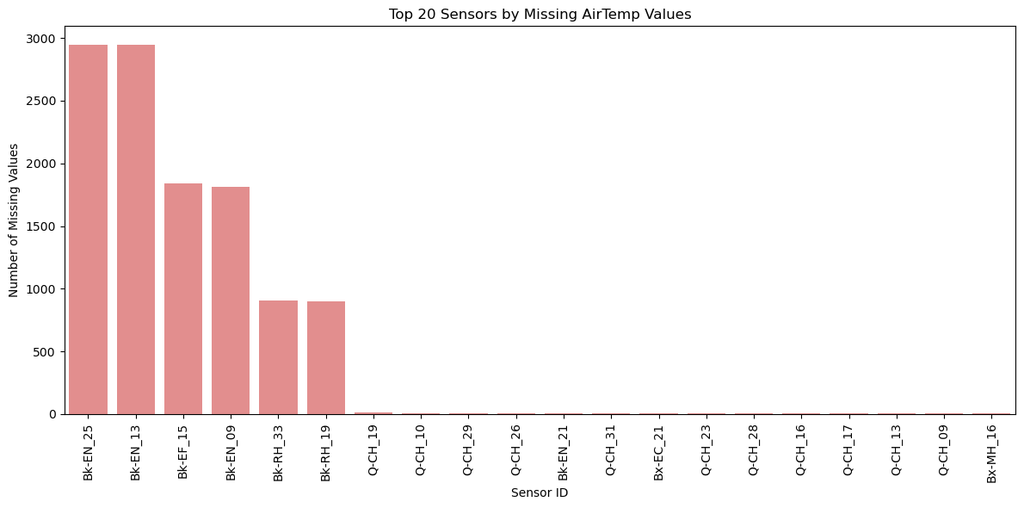

```python
import matplotlib.pyplot as plt
import seaborn as sns

# ====== 1. Prepare Data ======
# Count missing AirTemp per sensor
missing_per_sensor = nyc_hyper_local_temp.groupby('Sensor.ID')['AirTemp'].apply(lambda x: x.isna().sum())
# Filter out sensors with 0 missing values
missing_df_filtered = missing_per_sensor[missing_per_sensor > 0].reset_index()
missing_df_filtered.columns = ['Sensor.ID', 'MissingCount']
missing_df_filtered = missing_df_filtered.sort_values('MissingCount', ascending=False)

num_sensors = len(missing_df_filtered)

# ====== 2. Static Barplot (all sensors) ======
fig_width = max(12, num_sensors * 0.3)  # dynamic width
plt.figure(figsize=(fig_width,6))
sns.barplot(data=missing_df_filtered, x='Sensor.ID', y='MissingCount', color='skyblue')
plt.title('Missing AirTemp Values per Sensor (Sensors with >0 Missing)')
plt.xlabel('Sensor ID')
plt.ylabel('Number of Missing Values')
plt.xticks(rotation=90)

# Optional: skip labels if too many
if num_sensors > 50:
    for i, label in enumerate(plt.gca().get_xticklabels()):
        if i % 5 != 0:
            label.set_visible(False)

plt.tight_layout()
plt.show()

# ====== 3. Log-Scale Version ======
plt.figure(figsize=(fig_width,6))
sns.barplot(data=missing_df_filtered, x='Sensor.ID', y='MissingCount', color='lightgreen')
plt.yscale('log')
plt.title('Missing AirTemp Values per Sensor (Log Scale)')
plt.xlabel('Sensor ID')
plt.ylabel('Number of Missing Values (log scale)')
plt.xticks(rotation=90)
plt.tight_layout()
plt.show()

# ====== 4. Top N Sensors ======
top_n = 20
top_sensors = missing_df_filtered.head(top_n)
plt.figure(figsize=(12,6))
sns.barplot(data=top_sensors, x='Sensor.ID', y='MissingCount', color='lightcoral')
plt.title(f'Top {top_n} Sensors by Missing AirTemp Values')
plt.xlabel('Sensor ID')
plt.ylabel('Number of Missing Values')
plt.xticks(rotation=90)
plt.tight_layout()
plt.show()
```

Determine whether to drop sensors with any missing values

**Proposed Guidelines:**

If a sensor has >5–10% missing data or missing in contiguous blocks, it may bias analysis. Consider dropping it entirely.

If missing is <1% and spread randomly, dropping rows is usually fine. 11707 missing out of 2,097,150 → ~0.56%, very low.

Check impact by sensor:

```python
# Percentage of missing per sensor
sensor_missing_pct = (missing_per_sensor / nyc_hyper_local_temp.groupby('Sensor.ID')['AirTemp'].count()).sort_values(ascending=False)
sensor_missing_pct.head(10)
    # Observation of the sensors with the top ten highest fraction of missing temperature readings.
```

```
Sensor.ID
Bk-EN_25    1.000000
Bk-EN_13    1.000000
Bk-EF_15    0.452932
Bk-EN_09    0.443683
Bk-RH_33    0.441565
Bk-RH_19    0.440860
Q-CH_29     0.003062
Q-CH_31     0.002380
Q-CH_19     0.002039
Bx-EC_21    0.002039
Name: AirTemp, dtype: float64
```

**A few observations:**

2. Partially missing sensors:

3. Mostly complete sensors:

   ```
   Q-CH_29, Q-CH_31, Q-CH_19, and Bx-EC_21 are almost complete (<0.31% missing). These are safe to include without much preprocessing.
   ```

**Context-Aware Imputation Strategy**

Since there exists Datetime, Hour, Latitude, and Longitude, to now impute missing AirTemp by using nearby sensors at the same hour, or by hourly climatology per sensor.

The dataset contains multiple temperature sensors, some of which have many missing readings. Sensors with more than 50% missing values are considered unreliable and removed. This ensures that subsequent analysis and imputation are based on sensors with sufficient data coverage, improving the reliability of predictions.

The goal is to fill in the missing temperature values. To do this, three variables—**Hour of the day, Latitude, and Longitude**—are identified as informative predictors. These features are expected to explain spatial and temporal variations in temperature:

1. Hour captures daily temperature cycles.
2. Latitude and Longitude capture geographic differences and microclimates.

The dataset is split into two subsets:

1. Known temperatures (rows with recorded values).
2. Missing temperatures (rows where values need to be predicted).

This separation ensures that the model only learns from observed data.

**An Overview of K-Nearest Neighbours w.r.t. the Dataset**

In this development, a formal description of the KNN method (Cunningham & Delany, 2021) will not be detailed. Rather, an approach that's directly associated with the current pursuit.

The mathematical structure of a K-Nearest Neighbors (KNN) regressor for your temperature data relies on defining a multi-dimensional metric space. Since you are using Hour, Latitude, and Longitude, each trip (row) is represented as a point $P$ in a 3D vector space.

1. The Feature Vector. For any given observation $i$, the feature vector $x_i$ is defined as:

$$x_i=[h_i\,,\phi_i\,,\,\lambda_i]$$

where:

$h_i$ being the hour of the day,

$\phi_i$ being the latitude,

$\lambda_i$ being the longitude.

2. Distance Metric (Euclidean). To find "closeness," the model calculates the distance between a point with a missing temperature ($x_{miss}$) and all points with known temperatures ($x_{known}$). The standard metric is the Minkowski distance with $p=2$, commonly known as Euclidean Distance:

$$d(x_{miss}\,,x_{known})=\sqrt{(h_m-h_k)^2\,+\,(\phi_m-\phi_k)^2\,+\,(\lambda_m-\lambda_k)^2}$$

Since Latitude/Longitude differences are often very small (e.g., $0.01$) and Hour differences are large (e.g., $12$), we apply Standardization (Z-score normalization) so that each feature has a mean of 0 and a variance of 1. Without this, "Hour" would mathematically overwhelm the geographic coordinates.

3. Finding the Neighborhood ($\mathcal{N}$)The model identifies the set of indices $\mathcal{N}$ corresponding to the $k$ smallest distances:

$$\mathcal{N}=\{i_1\,,i_2\,,...,\,i_k\}$$

Commonly, $k=5$.

4. Weighted PredictionSince you specified that closeness is weighted by distance, the model doesn't just take a simple average. It uses an Inverse Distance Weighting.

First, a weight $w_i$ is calculated for each neighbor:

$$w_i=\frac{1}{d(x_{miss}\,,\,x_i)}$$

Then, the missing AirTemp $\hat{y}$ is predicted as the weighted average of the observed temperatures $y_i$ of the neighbors:

$$\hat{y} = \frac{\sum_{i \in \mathcal{N}} w_i y_i}{\sum_{i \in \mathcal{N}} w_i}$$

A **K-Nearest Neighbours (KNN) regressor** is used to predict missing temperatures. Conceptually:

1. For each missing point, the model finds the 5 closest points (neighbors) in the feature space defined by Hour, Latitude, and Longitude.
2. Closeness is weighted by distance, giving more influence to nearer neighbors.
3. The temperature prediction is a weighted average of these neighbors’ observed values.
4. The resulting $\hat{y}$ provides a "hyper-local" estimate that respects both the urban heat island effect (via coordinates) and the diurnal cycle (via hour).

This approach leverages the assumption that temperatures are locally similar in both space (geography) and time (hour of day).

The trained KNN model is applied to rows with missing temperatures. Each missing value is replaced with a predicted temperature based on its nearest neighbors. After this step, the dataset no longer contains gaps in the target variable.

Finally, a check is performed to ensure all missing values have been successfully imputed. A count of remaining missing temperatures should be zero, confirming that the imputation process is complete.

```python
import pandas as pd
import numpy as np
from sklearn.impute import KNNImputer
from sklearn.neighbors import KNeighborsRegressor
from sklearn.preprocessing import StandardScaler

# 1. Filter Unreliable Sensors (>50% missing)
sensor_stats = nyc_hyper_local_temp.groupby('Sensor.ID')['AirTemp'].apply(lambda x: x.isna().mean())
unreliable_sensors = sensor_stats[sensor_stats > 0.5].index

df_filtered = nyc_hyper_local_temp[~nyc_hyper_local_temp['Sensor.ID'].isin(unreliable_sensors)].copy()

print(f"Removed {len(unreliable_sensors)} sensors with >50% missing data.")

# 2. Prepare Features for Imputation
# We use Hour, Latitude, and Longitude as our feature matrix
features = ['Hour', 'Latitude', 'Longitude']

# 3. Split dataset into Known and Missing
# We only train the model on rows where we actually have a temperature
train_data = df_filtered[df_filtered['AirTemp'].notna()]
predict_data = df_filtered[df_filtered['AirTemp'].isna()]

if not predict_data.empty:
    # 4. Scaling
    # KNN is distance-based, so we must scale features so 'Hour' doesn't dominate 'Lat/Lon'
    scaler = StandardScaler()
    X_train = scaler.fit_transform(train_data[features])
    X_predict = scaler.transform(predict_data[features])
    y_train = train_data['AirTemp']

    # 5. Initialize and Run KNN Regressor
    # weights='distance' ensures closer neighbors have more influence
    knn = KNeighborsRegressor(n_neighbors=5, weights='distance')
    knn.fit(X_train, y_train)
    # Instead of just looking at what happened a minute ago, it looks at what is happening nearby at the same time,
         # which is often more accurate for "hyper-local" urban temperatures where a park might be cooler than a paved street just a block away.

    # 6. Impute missing values
    predicted_temps = knn.predict(X_predict)

    # Map predictions back to the original dataframe
    df_filtered.loc[df_filtered['AirTemp'].isna(), 'AirTemp'] = predicted_temps
       # In the code provided, we use Pandas indexing to ensure that each predicted temperature is mapped back to the specific row it belongs to.
       # Possesing a unique Datetime and set of coordinates for every reading, the model "looks up" the missing value's context (e.g., 2:00 PM at a specific Lat/Lon)
             # and injects the prediction into that specific slot.
       # Scikit-learn’s predict() function returns the results in the same order as the input features (X_predict).
             # Since (X_predict) was created from the missing rows in their original sequence, the results align perfectly.
       # Coordinate/Hour Integrity:
             # Because Hour, Latitude, and Longitude were the inputs for that specific row, the KNN regressor effectively "fills the gap" for those exact coordinates and that exact hour.

# 7. Final Verification
missing_count = df_filtered['AirTemp'].isna().sum()
print(f"Imputation complete. Remaining missing AirTemp values: {missing_count}")

# Assign back to your original variable name
nyc_hyper_local_temp = df_filtered
```

```
Removed 0 sensors with >50% missing data.
Imputation complete. Remaining missing AirTemp values: 0
```

```python
nyc_hyper_local_temp.info()
```

```
<class 'pandas.core.frame.DataFrame'>
RangeIndex: 2097150 entries, 0 to 2097149
Data columns (total 11 columns):
 #   Column        Dtype
---  ------        -----
 0   Sensor.ID     object
 1   AirTemp       float64
 2   Day           datetime64[ns]
 3   Hour          int64
 4   Datetime      datetime64[ns]
 5   Latitude      float64
 6   Longitude     float64
 7   Year          int64
 8   Install.Type  object
 9   Borough       object
 10  ntacode       object
dtypes: datetime64[ns](2), float64(3), int64(2), object(4)
memory usage: 176.0+ MB
```

```python
nyc_hyper_local_temp.isna().sum()
```

```
Sensor.ID       0
AirTemp         0
Day             0
Hour            0
Datetime        0
Latitude        0
Longitude       0
Year            0
Install.Type    0
Borough         0
ntacode         0
dtype: int64
```

### Elementary Geospatial Analysis for Sensors

Determining the amount of sensors in each borough:

```python
sensor_counts = (
    nyc_hyper_local_temp
        .groupby('Borough')['Sensor.ID']
        .nunique()
        .sort_values(ascending=False)
)

print(sensor_counts)
```

```
Borough
Brooklyn     166
Bronx        136
Manhattan     84
Queens        37
Name: Sensor.ID, dtype: int64
```

Observing spatial coverage consistency before modeling or time-series forecasting:

```python
nyc_hyper_local_temp.groupby(['Borough','Install.Type'])['Sensor.ID'].nunique()
```

```
Borough    Install.Type
Bronx      Light Pole       48
           Street Tree      88
Brooklyn   Light Pole       45
           Street Tree     122
Manhattan  Light Pole       16
           Street Tree      68
Queens     Light Pole        7
           Street Tree      30
Name: Sensor.ID, dtype: int64
```

## Spatial Clustering (MiniBatch KMeans)

**Purpose of Mini-Batch K-Means**

The main purpose of Mini-Batch K-Means (Sculley, 2010) is to provide a computationally efficient alternative to the standard K-Means algorithm when dealing with very large datasets. In this case, with approximately 2.1 million rows (instances) of NYC temperature data, a standard K-Means algorithm would likely struggle with memory overhead and slow convergence because it must calculate distances for every single data point in every iteration.

Key Advantages:

1. Scalability: It reduces the computational cost by using a randomly sampled "mini-batch" of data points in each iteration rather than the full dataset.
2. Memory Efficiency: It does not require the entire dataset to be stored in RAM simultaneously, making it ideal for large-scale urban climate sensor data.
3. Speed: It achieves significantly faster convergence, often with only a negligible decrease in the quality of the clusters (centroid positions).

**Basic Mathematical Structure**

1. Just like standard K-Means, the algorithm begins by chosing $k$ initial centroids, $C = \{c_1, c_2, \dots, c_k\}$, often using the **K-Means++** initialization to ensure better starting positions.
2. In each iteration t, a small subset of the data (a "mini-batch") M is randomly sampled from the full dataset X.

$$|M|<<|X|$$

3. For each point $x$ in the mini-batch $M$, the algorithm finds the nearest centroid $c_{closest}$ using the Euclidean distance:

$$\min_{c \in C} \|x - c\|^2$$

4. Rather than recalculating the centroid as the mean of all points assigned to it, Mini-Batch K-Means applies a learning rate or per-centroid counter to update the position. For each point $x$ in the batch assigned to centroid $c_i$:

-Increment the count: $v_i \leftarrow v_i + 1$ (where $v_i$ is the number of points assigned to centroid $c_i$ so far).

-Calculate the per-point learning rate: $\eta = \frac{1}{v_i}$.

-Update the centroid:

$$c_i\,\leftarrow\,(1-\eta)c_i+\eta\,x$$

The above formula can be viewed as a moving average. It pulls the centroid slightly toward the new data point sans disregarding the information from previous batches.

5. The process repeats for a fixed number of iterations or until the centroids stabilize (change by less than a predefined threshold).

#### Whole Dataset MiniBatch

Preparation of festures:

```python
import numpy as np
import pandas as pd
from sklearn.preprocessing import StandardScaler

features = ['Latitude','Longitude','AirTemp']

X = nyc_hyper_local_temp[features]

scaler = StandardScaler()  # Standardization or normalisation of features so that one may not "drown the other"
Xs = scaler.fit_transform(X)
```

Sample for Silhouette search:

```python
sample_size = 100_000   # safe + fast
idx = np.random.choice(len(Xs), sample_size, replace=False)
Xs_sample = Xs[idx]
```

Evaluate k via Silhouette:

```python
from sklearn.cluster import MiniBatchKMeans
from sklearn.metrics import silhouette_score
import matplotlib.pyplot as plt

ks = range(2, 8)
scores = []

for k in ks:
    km = MiniBatchKMeans(n_clusters=k, batch_size=10000, random_state=42)
    labels = km.fit_predict(Xs_sample)
    score = silhouette_score(Xs_sample, labels)
    scores.append(score)
    print(f"k={k}  silhouette={score:.4f}")
```

```
k=2  silhouette=0.3336
k=3  silhouette=0.3160
k=4  silhouette=0.3999
k=5  silhouette=0.3481
k=6  silhouette=0.3651
k=7  silhouette=0.3474
```

Silhouette Plot:

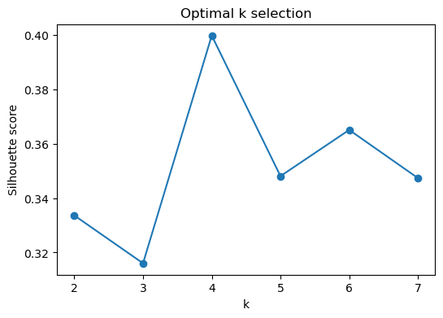

```python
plt.figure(figsize=(6,4))
plt.plot(ks, scores, marker='o')
plt.xlabel("k")
plt.ylabel("Silhouette score")
plt.title("Optimal k selection")
plt.show()
```

Optimak k choice:

```python
optimal_k = ks[np.argmax(scores)]
print("Optimal k:", optimal_k)
```

```
Optimal k: 4
```

Fitting final clustering with optimal k:

```python
kmeans = MiniBatchKMeans(
    n_clusters=optimal_k,
    batch_size=50000,
    random_state=42
)

labels = kmeans.fit_predict(Xs)

nyc_hyper_local_temp.loc[X.index, 'cluster'] = labels
```

Geospatial cluster plots:

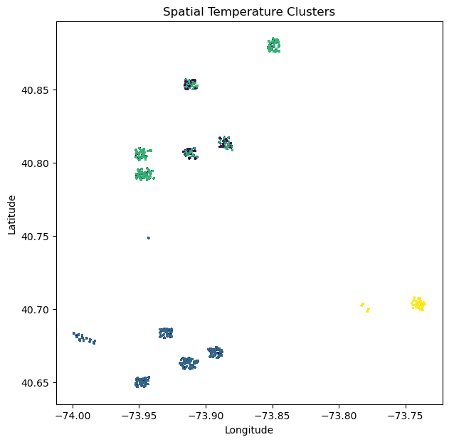

```python
plt.figure(figsize=(7,7))
plt.scatter(
    nyc_hyper_local_temp['Longitude'],
    nyc_hyper_local_temp['Latitude'],
    c=nyc_hyper_local_temp['cluster'],
    s=1
)
plt.xlabel("Longitude")
plt.ylabel("Latitude")
plt.title("Spatial Temperature Clusters")
plt.show()
```

```python
city_cluster_centroids = (
    nyc_hyper_local_temp
        .groupby(['cluster'])[['Latitude','Longitude']]
        .mean()
        .reset_index()
)

city_cluster_centroids
```

|  | cluster | Latitude | Longitude |
| --- | --- | --- | --- |
| 0 | 0.0 | 40.810975 | -73.917110 |
| 1 | 1.0 | 40.666937 | -73.924757 |
| 2 | 2.0 | 40.820408 | -73.913793 |
| 3 | 3.0 | 40.702991 | -73.743033 |

Mean Temperature per City Cluster (Interpretability)

If cluster means differ → physically distinct microclimates.

```python
nyc_hyper_local_temp.groupby(['cluster'])['AirTemp'].mean()
```

```
cluster
0.0    85.088437
1.0    75.438831
2.0    70.064297
3.0    75.312059
Name: AirTemp, dtype: float64
```

#### Per Borough Optimal k & Clustering

To now develop clusteribg for a respective borough. Such less globular approach can be more statistically correct since each borough may have different density/variance.

```python
from sklearn.metrics import silhouette_score

def cluster_borough(df, k_range=range(2,10), sample_size=20000):
    X = df[features]
    Xs = StandardScaler().fit_transform(X)

    if len(Xs) > sample_size:
        idx = np.random.choice(len(Xs), sample_size, replace=False)
        Xs_sample = Xs[idx]
    else:
        Xs_sample = Xs

    scores = []
    for k in k_range:
        labels = MiniBatchKMeans(k, batch_size=5000).fit_predict(Xs_sample)
        scores.append(silhouette_score(Xs_sample, labels))

    best_k = list(k_range)[np.argmax(scores)]

    final_labels = MiniBatchKMeans(best_k, batch_size=5000).fit_predict(Xs)

    out = pd.Series(final_labels, index=X.index)

    return out, best_k, scores
```

Clusters in the boroughs:

The succeeding code performs separate clustering within each borough of New York City rather than clustering the entire dataset at once. It first splits the dataframe by Borough, then for each subset it runs cluster_borough(), which uses silhouette scores to determine the optimal number of clusters (k) and applies MiniBatchKMeans to assign cluster labels.

For every borough, the optimal k is stored in a dictionary (borough_k), while the resulting cluster labels are collected and concatenated back into the main dataframe as a new column (borough_cluster).

The outcome is locally optimized spatial–temperature clusters per borough, producing more meaningful and statistically reliable groupings than a single global clustering, since each borough has different density, geography, and thermal behavior.

```python
borough_labels = []
borough_k = {}

for b, d in nyc_hyper_local_temp.groupby('Borough'):
    labels, k, scores = cluster_borough(d)
    borough_k[b] = k
    borough_labels.append(labels)

nyc_hyper_local_temp['borough_cluster'] = pd.concat(borough_labels).sort_index()

print(borough_k)
```

```
{'Bronx': 9, 'Brooklyn': 4, 'Manhattan': 2, 'Queens': 4}
```

View of gebneral clustering versus borough cluster:

```python
nyc_hyper_local_temp
```

|  | Sensor.ID | AirTemp | Day | Hour | Datetime | Latitude | Longitude | Year | Install.Type | Borough | ntacode | cluster | borough_cluster |
| --- | --- | --- | --- | --- | --- | --- | --- | --- | --- | --- | --- | --- | --- |
| 0 | Bk-BR_01 | 71.189000 | 2018-06-15 | 1 | 2018-06-15 01:00:00 | 40.666205 | -73.91691 | 2018 | Street Tree | Brooklyn | BK81 | 1.0 | 0 |
| 1 | Bk-BR_01 | 70.243333 | 2018-06-15 | 2 | 2018-06-15 02:00:00 | 40.666205 | -73.91691 | 2018 | Street Tree | Brooklyn | BK81 | 1.0 | 0 |
| 2 | Bk-BR_01 | 69.392667 | 2018-06-15 | 3 | 2018-06-15 03:00:00 | 40.666205 | -73.91691 | 2018 | Street Tree | Brooklyn | BK81 | 1.0 | 0 |
| 3 | Bk-BR_01 | 68.263167 | 2018-06-15 | 4 | 2018-06-15 04:00:00 | 40.666205 | -73.91691 | 2018 | Street Tree | Brooklyn | BK81 | 1.0 | 0 |
| 4 | Bk-BR_01 | 67.114000 | 2018-06-15 | 5 | 2018-06-15 05:00:00 | 40.666205 | -73.91691 | 2018 | Street Tree | Brooklyn | BK81 | 1.0 | 0 |
| ... | ... | ... | ... | ... | ... | ... | ... | ... | ... | ... | ... | ... | ... |
| 2097145 | Q-CH_26 | 78.346667 | 2019-09-07 | 15 | 2019-09-07 15:00:00 | 40.699578 | -73.73876 | 2019 | Light Pole | Queens | QN33 | 3.0 | 0 |
| 2097146 | Q-CH_26 | 79.517167 | 2019-09-07 | 16 | 2019-09-07 16:00:00 | 40.699578 | -73.73876 | 2019 | Light Pole | Queens | QN33 | 3.0 | 0 |
| 2097147 | Q-CH_26 | 77.203667 | 2019-09-07 | 17 | 2019-09-07 17:00:00 | 40.699578 | -73.73876 | 2019 | Light Pole | Queens | QN33 | 3.0 | 0 |
| 2097148 | Q-CH_26 | 75.696000 | 2019-09-07 | 18 | 2019-09-07 18:00:00 | 40.699578 | -73.73876 | 2019 | Light Pole | Queens | QN33 | 3.0 | 0 |
| 2097149 | Q-CH_26 | 72.359000 | 2019-09-07 | 19 | 2019-09-07 19:00:00 | 40.699578 | -73.73876 | 2019 | Light Pole | Queens | QN33 | 3.0 | 2 |

2097150 rows × 13 columns

Fast Static Per Borough Cluster Plots:

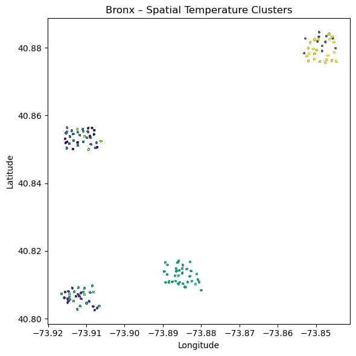

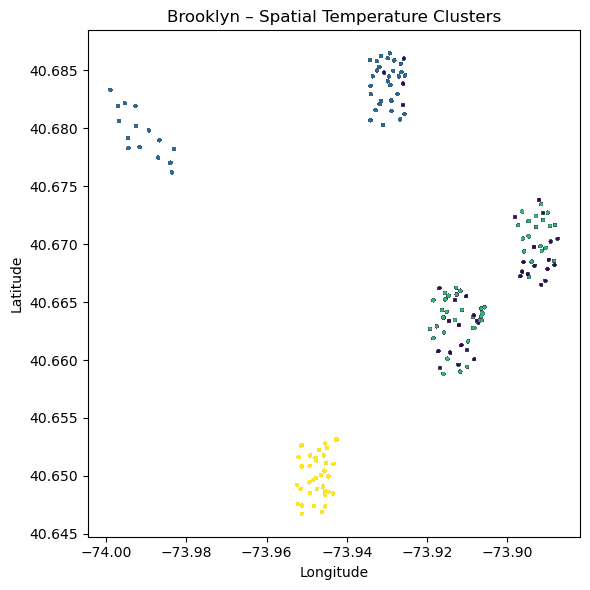

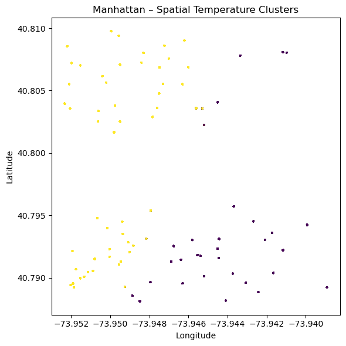

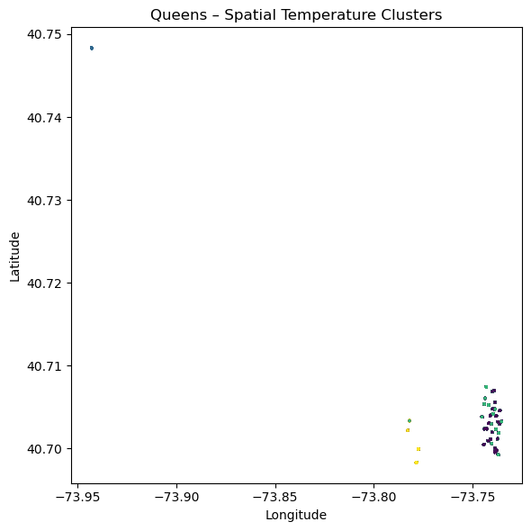

```python
import matplotlib.pyplot as plt

sample_n = 50_000  # speed safeguard

for b, d in nyc_hyper_local_temp.groupby('Borough'):

    ds = d.sample(min(sample_n, len(d)), random_state=42)

    plt.figure(figsize=(6,6))
    plt.scatter(
        ds['Longitude'],
        ds['Latitude'],
        c=ds['borough_cluster'],
        s=2
    )

    plt.title(f"{b} – Spatial Temperature Clusters")
    plt.xlabel("Longitude")
    plt.ylabel("Latitude")
    plt.tight_layout()
    plt.show()
```

Borough cluster centroids:

```python
borough_cluster_centroids = (
    nyc_hyper_local_temp
        .groupby(['Borough','borough_cluster'])[['Latitude','Longitude']]
        .mean()
        .reset_index()
)

borough_cluster_centroids
```

|  | Borough | borough_cluster | Latitude | Longitude |
| --- | --- | --- | --- | --- |
| 0 | Bronx | 0 | 40.853486 | -73.911457 |
| 1 | Bronx | 1 | 40.806209 | -73.912053 |
| 2 | Bronx | 2 | 40.879938 | -73.848713 |
| 3 | Bronx | 3 | 40.853520 | -73.911482 |
| 4 | Bronx | 4 | 40.812735 | -73.885310 |
| 5 | Bronx | 5 | 40.809834 | -73.896820 |
| 6 | Bronx | 6 | 40.809685 | -73.897965 |
| 7 | Bronx | 7 | 40.853638 | -73.911554 |
| 8 | Bronx | 8 | 40.879988 | -73.848668 |
| 9 | Brooklyn | 0 | 40.666798 | -73.905986 |
| 10 | Brooklyn | 1 | 40.682959 | -73.942244 |
| 11 | Brooklyn | 2 | 40.666386 | -73.903567 |
| 12 | Brooklyn | 3 | 40.649986 | -73.947525 |
| 13 | Manhattan | 0 | 40.793086 | -73.944427 |
| 14 | Manhattan | 1 | 40.801093 | -73.949518 |
| 15 | Queens | 0 | 40.703116 | -73.740465 |
| 16 | Queens | 1 | 40.748326 | -73.942779 |
| 17 | Queens | 2 | 40.703143 | -73.740336 |
| 18 | Queens | 3 | 40.701026 | -73.780432 |

Mean Temperature per Borough Cluster (Interpretability)

If cluster means differ → physically distinct microclimates.

```python
nyc_hyper_local_temp.groupby(['Borough','borough_cluster'])['AirTemp'].mean()
```

```
Borough    borough_cluster
Bronx      0                  86.178927
           1                  75.742070
           2                  82.408908
           3                  74.219524
           4                  75.152152
           5                  89.034800
           6                  61.868062
           7                  62.168486
           8                  68.118204
Brooklyn   0                  67.619333
           1                  76.618781
           2                  82.017154
           3                  76.339609
Manhattan  0                  76.085611
           1                  76.178994
Queens     0                  82.481198
           1                  71.911015
           2                  68.441713
           3                  75.791945
Name: AirTemp, dtype: float64
```

## Outlier Detection per Borough

Outlier detection (also known as anomaly detection) is identified as a data mining or machine learning process used to identify data points, events, or observations that veer significantly from the rest of the dataset. These "peculiar ones" often indicate critical information such as (based on our setting and interest) technical errors or extreme event.

Outlier detection leans on defining what is considered normal (as in status quo, not Gaussian) behaviour for a dataset. Anything that does not fit this profile is flagged.

**Histogram-based Outlier Score (HBOS)**

1. HBOS (Goldstein and Dittrich, 2012) is a global unsupervised detection algorithm. It assumes that features are independent and calculates an anomaly score by constructing histograms for each feature.
2. For every instance (row), it looks at each attribute (e.g., AirTemp, Hour, etc., etc). If a instance falls into a "frequent" bin (a tall bar in the histogram), it gets a low score. If it falls into an infrequent bin, it gets a high score. The individual scores are then summed or multiplied.
3. Key Advantage: It is **extremely fast**. Since it doesn't calculate distances between points, it has a linear complexity $O(n)$.
4. Best Use Case: Finding "obvious" outliers, like a temperature reading that is $x$ when the average is $g$.

**Local Outlier Factor (LOF)**

1. LOF (Breunig et al, 2000) is a local density-based algorithm. Instead of looking at the whole dataset, it compares the density of a data point to the density of its neighbours.
2. It applies the $k$-nearest neighbors ($k$-NN) approach (**encountered earlier with data cleaning**). A point is considered an outlier if its local density is significantly lower than that of its neighbours. In the temperature data, a particular temperature reading might be "normal" globally, but if it sits in a cluster where every other same/similar reading is associated to a time (for example) that is drastically unique, LOF will flag it.
3. LOF relies on "reachability distance." If we define $lrd(A)$ as the local reachability density of point $A$, the LOF is:

$$LOF_k(A) = \frac{\sum_{B \in N_k(A)} \frac{lrd(B)}{lrd(A)}}{|N_k(A)|}$$

4. It can find outliers that would be missed by global methods because it understands the "context" of the surrounding data.
5. Best Use Case: Detecting "sneaky" anomalies—readings that look normal on paper but are weird relative to their specific peer group.

Preparation of features array:

```python
features = ['AirTemp','Latitude','Longitude','Hour']
```

HBOS build:

```python
!pip install pyod
```

```python
from pyod.models.hbos import HBOS

def hbos_detect(df):
    model = HBOS()
    X = df[features].values  # ensure numpy array
    model.fit(X)             # fit first
    return model.predict(X)  # then predict


nyc_hyper_local_temp['hbos_flag'] = (
    nyc_hyper_local_temp
        .groupby('Borough', group_keys=False)
        .apply(
            lambda d: pd.Series(hbos_detect(d[features]), index=d.index),
            include_groups=False
        )
)
```

In pyod.models.hbos.HBOS().predict(X) or fit_predict(X):

Value 0 $\rightarrow$ Inlier (normal point)

Value 1 $\rightarrow$ Outlier

```python
HBOS_outliers= nyc_hyper_local_temp[nyc_hyper_local_temp['hbos_flag'] == 1]
HBOS_outliers
```

|  | Sensor.ID | AirTemp | Day | Hour | Datetime | Latitude | Longitude | Year | Install.Type | Borough | ntacode | cluster | borough_cluster | hbos_flag |
| --- | --- | --- | --- | --- | --- | --- | --- | --- | --- | --- | --- | --- | --- | --- |
| 29480 | Bk-BR_12 | 70.640750 | 2018-06-15 | 1 | 2018-06-15 01:00:00 | 40.660060 | -73.908200 | 2018 | Light Pole | Brooklyn | BK81 | 1.0 | 0 | 1 |
| 29481 | Bk-BR_12 | 69.492500 | 2018-06-15 | 2 | 2018-06-15 02:00:00 | 40.660060 | -73.908200 | 2018 | Light Pole | Brooklyn | BK81 | 1.0 | 0 | 1 |
| 29482 | Bk-BR_12 | 68.606333 | 2018-06-15 | 3 | 2018-06-15 03:00:00 | 40.660060 | -73.908200 | 2018 | Light Pole | Brooklyn | BK81 | 1.0 | 0 | 1 |
| 29483 | Bk-BR_12 | 67.370500 | 2018-06-15 | 4 | 2018-06-15 04:00:00 | 40.660060 | -73.908200 | 2018 | Light Pole | Brooklyn | BK81 | 1.0 | 0 | 1 |
| 29484 | Bk-BR_12 | 66.336167 | 2018-06-15 | 5 | 2018-06-15 05:00:00 | 40.660060 | -73.908200 | 2018 | Light Pole | Brooklyn | BK81 | 1.0 | 0 | 1 |
| ... | ... | ... | ... | ... | ... | ... | ... | ... | ... | ... | ... | ... | ... | ... |
| 2092151 | Q-CH_24 | 50.245333 | 2019-10-15 | 5 | 2019-10-15 05:00:00 | 40.705384 | -73.744145 | 2019 | Street Tree | Queens | QN34 | 3.0 | 2 | 1 |
| 2092152 | Q-CH_24 | 49.227167 | 2019-10-15 | 6 | 2019-10-15 06:00:00 | 40.705384 | -73.744145 | 2019 | Street Tree | Queens | QN34 | 3.0 | 2 | 1 |
| 2092156 | Q-CH_24 | 58.059000 | 2019-10-15 | 10 | 2019-10-15 10:00:00 | 40.705384 | -73.744145 | 2019 | Street Tree | Queens | QN34 | 3.0 | 2 | 1 |
| 2092165 | Q-CH_24 | 58.008833 | 2019-10-15 | 19 | 2019-10-15 19:00:00 | 40.705384 | -73.744145 | 2019 | Street Tree | Queens | QN34 | 3.0 | 2 | 1 |
| 2092166 | Q-CH_24 | 57.506000 | 2019-10-15 | 20 | 2019-10-15 20:00:00 | 40.705384 | -73.744145 | 2019 | Street Tree | Queens | QN34 | 3.0 | 2 | 1 |

207937 rows × 14 columns

LOF build:

```python
from sklearn.neighbors import LocalOutlierFactor

def lof_detect(df):
    lof = LocalOutlierFactor(n_neighbors=50, contamination=0.01)
    X = df[features].copy()
    X += np.random.normal(0, 1e-6, X.shape)  # optional jitter
    return lof.fit_predict(X)


nyc_hyper_local_temp['lof_flag'] = (
    nyc_hyper_local_temp
        .groupby('Borough', group_keys=False)
        .apply(
            lambda d: pd.Series(lof_detect(d[features]), index=d.index),
            include_groups=False
        )
)
```

In sklearn.neighbors.LocalOutlierFactor.fit_predict():

Value 1 $\rightarrow$ Inlier (normal point)

Value -1 $\rightarrow$ Outlier

```python
LOF_outliers= nyc_hyper_local_temp[nyc_hyper_local_temp['lof_flag'] == -1]
LOF_outliers
```

|  | Sensor.ID | AirTemp | Day | Hour | Datetime | Latitude | Longitude | Year | Install.Type | Borough | ntacode | cluster | borough_cluster | hbos_flag | lof_flag |
| --- | --- | --- | --- | --- | --- | --- | --- | --- | --- | --- | --- | --- | --- | --- | --- |
| 68 | Bk-BR_01 | 75.919333 | 2018-06-17 | 21 | 2018-06-17 21:00:00 | 40.666205 | -73.916910 | 2018 | Street Tree | Brooklyn | BK81 | 1.0 | 2 | 0 | -1 |
| 127 | Bk-BR_01 | 73.127500 | 2018-06-20 | 8 | 2018-06-20 08:00:00 | 40.666205 | -73.916910 | 2018 | Street Tree | Brooklyn | BK81 | 1.0 | 0 | 0 | -1 |
| 344 | Bk-BR_01 | 80.618333 | 2018-06-29 | 9 | 2018-06-29 09:00:00 | 40.666205 | -73.916910 | 2018 | Street Tree | Brooklyn | BK81 | 1.0 | 2 | 0 | -1 |
| 474 | Bk-BR_01 | 81.620000 | 2018-07-04 | 19 | 2018-07-04 19:00:00 | 40.666205 | -73.916910 | 2018 | Street Tree | Brooklyn | BK81 | 1.0 | 2 | 0 | -1 |
| 585 | Bk-BR_01 | 80.773167 | 2018-07-09 | 10 | 2018-07-09 10:00:00 | 40.666205 | -73.916910 | 2018 | Street Tree | Brooklyn | BK81 | 1.0 | 2 | 0 | -1 |
| ... | ... | ... | ... | ... | ... | ... | ... | ... | ... | ... | ... | ... | ... | ... | ... |
| 2094814 | Q-CH_25 | 55.363667 | 2019-10-03 | 8 | 2019-10-03 08:00:00 | 40.702333 | -73.738153 | 2019 | Street Tree | Queens | QN33 | 3.0 | 2 | 0 | -1 |
| 2095433 | Q-CH_26 | 85.268167 | 2019-06-28 | 7 | 2019-06-28 07:00:00 | 40.699578 | -73.738760 | 2019 | Light Pole | Queens | QN33 | 3.0 | 0 | 0 | -1 |
| 2095977 | Q-CH_26 | 89.815667 | 2019-07-20 | 23 | 2019-07-20 23:00:00 | 40.699578 | -73.738760 | 2019 | Light Pole | Queens | QN33 | 3.0 | 0 | 0 | -1 |
| 2095980 | Q-CH_26 | 86.800000 | 2019-07-21 | 2 | 2019-07-21 02:00:00 | 40.699578 | -73.738760 | 2019 | Light Pole | Queens | QN33 | 3.0 | 0 | 0 | -1 |
| 2095984 | Q-CH_26 | 83.601167 | 2019-07-21 | 6 | 2019-07-21 06:00:00 | 40.699578 | -73.738760 | 2019 | Light Pole | Queens | QN33 | 3.0 | 0 | 0 | -1 |

20973 rows × 15 columns

**Contrast Analysis between HBOS flags and LOF flags**

Observed on ~2.1M rows in New York City:

1. HBOS: 207,937 flagged (~10%)
2. LOF: 20,973 flagged (~1%)

Being almost a 10 times difference, which is substantial.

Yet, this is actually expected because:

1. HBOS → global histogram density (flags broad distribution tails)
2. LOF → local density contrast (flags only locally isolated points)

So they detect different anomaly types.

How different are the two methods and where do they disagree?

Overlap / Agreement (confusion-style table):

```python
df = nyc_hyper_local_temp.copy()

df['lof_out']  = df['lof_flag']  == -1
df['hbos_out'] = df['hbos_flag'] == 1
```

Crosstab:

```python
pd.crosstab(df['lof_out'], df['hbos_out'])
```

| hbos_out lof_out | False | True |
| --- | --- | --- |
| False | 1876267 | 199910 |
| True | 12946 | 8027 |

Agreement metrics (quantitative) - Jaccard similarity for overlap quality (Pedregosa et al, 2011):

```python
from sklearn.metrics import jaccard_score

jaccard_score(df['lof_out'], df['hbos_out'])
```

```
0.0363405060597692
```

near 1 → same flags

near 0 → totally different

expect 0.1–0.4 typically

Cohen’s kappa (McHugh, 2012) - chance-adjusted agreement:

```python
from sklearn.metrics import cohen_kappa_score

cohen_kappa_score(df['lof_out'], df['hbos_out'])
```

```
0.05292507942497515
```

For Cohen's kappa, Values $\leq$ 0 as indicating no agreement and 0.01–0.20 as none to slight, 0.21–0.40 as fair, 0.41– 0.60 as moderate, 0.61–0.80 as substantial, and 0.81–1.00 as almost perfect agreement.

Temporal comparison:

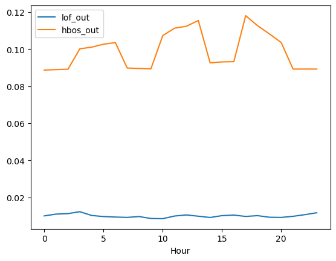

```python
hour_compare = (
    df.groupby('Hour')[['lof_out','hbos_out']]
      .mean()
)

hour_compare.plot()
```

Distributional diagnostics - checking what each method thinks is “abnormal”:

```python
df.groupby('hbos_out')['AirTemp'].describe()
```

| hbos_out | count | mean | std | min | 25% | 50% | 75% | max |
| --- | --- | --- | --- | --- | --- | --- | --- | --- |
| False | 1889213.0 | 75.984370 | 8.838557 | 46.031 | 70.694500 | 75.695500 | 81.738167 | 113.156833 |
| True | 207937.0 | 76.016876 | 10.214662 | 46.031 | 69.807167 | 75.911833 | 82.982833 | 114.963667 |

```python
df.groupby('lof_out')['AirTemp'].describe()
```

| lof_out | count | mean | std | min | 25% | 50% | 75% | max |
| --- | --- | --- | --- | --- | --- | --- | --- | --- |
| False | 2076177.0 | 75.992988 | 8.958895 | 46.0310 | 70.6155 | 75.709000 | 81.836333 | 110.929500 |
| True | 20973.0 | 75.453449 | 11.215129 | 46.0985 | 70.8770 | 76.515167 | 82.538500 | 114.963667 |

Defining tiers:

```python
df['tier'] = 'normal'
df.loc[df['hbos_out'], 'tier'] = 'global_extreme'
df.loc[df['lof_out'], 'tier'] = 'local_anomaly'
df.loc[df['hbos_out'] & df['lof_out'], 'tier'] = 'high_confidence'
```

Comparing temperature distributions:

```python
df.groupby('tier')['AirTemp'].describe()
```

| tier | count | mean | std | min | 25% | 50% | 75% | max |
| --- | --- | --- | --- | --- | --- | --- | --- | --- |
| global_extreme | 199910.0 | 75.988278 | 10.270450 | 46.0310 | 69.678167 | 75.876667 | 83.035333 | 110.691833 |
| high_confidence | 8027.0 | 76.729103 | 8.680984 | 46.2185 | 72.286417 | 76.506500 | 81.805583 | 114.963667 |
| local_anomaly | 12946.0 | 74.662496 | 12.466542 | 46.0985 | 67.549208 | 76.535583 | 82.909458 | 113.156833 |
| normal | 1876267.0 | 75.993490 | 8.807651 | 46.0310 | 70.701667 | 75.688500 | 81.731000 | 110.929500 |

Hourly pattern among tiers:

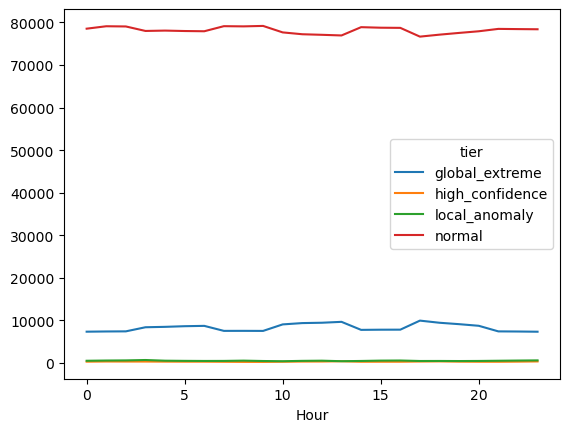

```python
df.groupby(['Hour','tier']).size().unstack().plot()
```

**IDEAS:**

**HBOS only (~200k)- Likely:**

• hot/cold extremes

• seasonal shifts

• regional weather regimes

• distribution tails

These (HBOS flags) are global anomalies -Good for:

✔ heatwaves

✔ cold snaps

✔ climate extremes

**LOF only (~13k) - Likely:**

• single sensor spikes

• hardware faults

• local micro-climate oddities

• spatially inconsistent temps

These (LOF flags) are local anomalies - Good for:

✔ sensor QC

✔ malfunction detection

✔ local shocks

**Both (~8k) ← most important - These are:**

• globally extreme AND locally isolated

Highest confidence anomalies - Best candidates for:

✔ event studies

✔ extreme weather episodes

✔ further investigation

## Time Series Analysis

Firstly, review of the dataframe:

```python
nyc_hyper_local_temp.info()
```

```
<class 'pandas.core.frame.DataFrame'>
RangeIndex: 2097150 entries, 0 to 2097149
Data columns (total 15 columns):
 #   Column           Dtype
---  ------           -----
 0   Sensor.ID        object
 1   AirTemp          float64
 2   Day              datetime64[ns]
 3   Hour             int64
 4   Datetime         datetime64[ns]
 5   Latitude         float64
 6   Longitude        float64
 7   Year             int64
 8   Install.Type     object
 9   Borough          object
 10  ntacode          object
 11  cluster          float64
 12  borough_cluster  int32
 13  hbos_flag        int64
 14  lof_flag         int64
dtypes: datetime64[ns](2), float64(4), int32(1), int64(4), object(4)
memory usage: 232.0+ MB
```

To capture the continental and diurnal temperature behaviors across New York City, there needs to be transition from raw sensor data to a set of spatially representative time series. To capture the "continental" (spatial) and "diurnal" (time-of-day) temperature behaviors, we will first aggregate the sensors by their cardinal extremes. First, to isolate the top 30 sensors for each cardinal extremity and the center. We identify these by sorting the unique Sensor.ID coordinates.

```python
import pandas as pd
import numpy as np
import matplotlib.pyplot as plt
from statsmodels.tsa.stattools import adfuller, kpss, coint


# =====================================================
# Building the geographic sensor groups
# =====================================================

sensors = (
    nyc_hyper_local_temp[['Sensor.ID', 'Latitude', 'Longitude']]
    .drop_duplicates()
)

groups = {
    'Northern': sensors.nlargest(30, 'Latitude')['Sensor.ID'],
    'Southern': sensors.nsmallest(30, 'Latitude')['Sensor.ID'],
    'Eastern':  sensors.nlargest(30, 'Longitude')['Sensor.ID'],
    'Western':  sensors.nsmallest(30, 'Longitude')['Sensor.ID']
}

# Central group
mean_lat, mean_lon = sensors['Latitude'].mean(), sensors['Longitude'].mean()

sensors['dist_to_center'] = np.sqrt(
    (sensors['Latitude'] - mean_lat)**2 +
    (sensors['Longitude'] - mean_lon)**2
)

groups['Central'] = sensors.nsmallest(30, 'dist_to_center')['Sensor.ID']
```

From observation of the data structure, we assume each row is an independent reading, so we must group by Datetime to create a synchronized time series, because we need a continuous timeline. We will average the AirTemp for these IDs across the Datetime column.

```python
# =====================================================
# Building the averaged time series
# =====================================================

ts_dict = {}

for name, ids in groups.items():
    ts_dict[name] = (
        nyc_hyper_local_temp[
            nyc_hyper_local_temp['Sensor.ID'].isin(ids)
        ]
        .groupby('Datetime')['AirTemp']
        .mean()
    )

df_ts = pd.DataFrame(ts_dict).dropna()

print("\nTime series shape:", df_ts.shape)
print(df_ts.head())
```

```
Time series shape: (2948, 5)
                      Northern   Southern    Eastern    Western    Central
Datetime
2018-06-15 01:00:00  68.192933  71.516149  69.816276  71.210125  70.496037
2018-06-15 02:00:00  67.128706  70.304472  68.522379  70.262150  69.705420
2018-06-15 03:00:00  66.278389  69.436930  67.912989  69.173317  68.807031
2018-06-15 04:00:00  65.480750  68.572490  67.197092  68.033183  67.602438
2018-06-15 05:00:00  64.216128  67.135785  65.922879  66.676150  66.115216
```

**The Idea of Stationarity:**

A stationary time series is one whose statistical properties—mean, variance, and autocorrelation—do not change over time. In the NYC temperature context, stationarity is the "baseline" behaviour. If a series is stationary, it doesn't matter when you look at the data; the "rules" governing its fluctuations remain the same.

**The Three Pillars of Stationarity:**

For a time series to be considered "strictly" stationary, it must satisfy three conditions:

1. Constant Mean: The series horizontally fluctuates around a fixed value. It doesn't "drift" upward or downward over the long term.
2. Constant Variance: The "amplitude" of the swings remains consistent. You don't see tiny ripples at 8:00 AM and massive spikes at 2:00 PM.
3. Constant Autocorrelation: The relationship between today’s temp and yesterday’s temp depends only on the distance (lag) between them, not the actual time.

**To proceed to cointegration, the individual series must be non-stationary**.

**Why Stationarity is Adversarial toward Coimtegration**

For the specific goal of cointegration, stationarity is actually something to disprove first. Conceptual reasoning:

1. The Drift: For two things to be "cointegrated," they must first be "wandering" (Non-Stationary). Think of a drunk person and their dog. Individually, they both wander aimlessly (Non-Stationary). However, the leash keeps them together.
2. The Leash: Cointegration is the "leash." It means that while the Northern and Southern temperatures are both non-stationary, the difference between them (the spread) is stationary.

The **Augmented Dickey-Fuller (ADF) test** is a statistical tool used to determine whether a time series is stationary or non-stationary (Cheung & Lai, 1995). In the context of your NYC temperature data, this is the "gatekeeper" test: you cannot perform cointegration analysis unless you first prove your temperature series are non-stationary.

Model the series $y_t$ as an autoregression:

$$y_t = \rho y_{t-1} + \sum_{i=1}^{p}\phi_i \Delta y_{t-i} + \varepsilon_t$$

Rewrite using first differences:

$$\Delta y_t = \gamma y_{t-1} + \sum_{i=1}^{p}\phi_i \Delta y_{t-i} + \varepsilon_t$$

Hypotheses:

$$H_0: \gamma = 0 \quad (\rho = 1, \text{unit root, non-stationary})$$

$$H_1 : \gamma < 0 \,\, (\text{stationary})$$

Decision for non-stationarity:

$$\text{p-value} > \alpha \;\Rightarrow\; \text{fail to reject } H_0 \;\Rightarrow\; \text{non-stationary}$$

The **KPSS (Kwiatkowski–Phillips–Schmidt–Shin) test** is the "skeptical" counterpart to the ADF test. While ADF starts by assuming the NYC temperature data is non-stationary, KPSS starts with the opposite assumption. In modern econometrics, using both tests together is called Confirmatory Analysis.

Decompose series into deterministic trend + random walk:

$$y_t = \delta t + r_t + \varepsilon_t$$

where the stochastic component is:

$$r_t = r_{t-1} + u_t$$

If $u_t\neq\,0$, the process has a **random walk** → **non-stationary**.

Hypotheses:

$$H_0: \sigma_u^2 = 0 \text{ (stationary)}$$

$$H_1: \sigma_u^2 > 0 \text{ (unit root, non-stationary)}$$

Test statistic:

$$\text{KPSS} = \frac{1}{T^2 \hat{\sigma}^2} \sum_{t=1}^{T} S_t^2 $$

Decision for non-stationarity:

$$\text{p-value} < \alpha \;\Rightarrow\; \text{reject } H_0 \;\Rightarrow\; \text{non-stationary}$$

COMBINED PRACTICAL RULE:

$$\text{ADF p-value > 0.05 and KPSS p-value < 0.05} \;\Rightarrow\; \text{strong evidence of non-stationarity} $$

```python
# =====================================================
# Testing for Non-Stationarity testing
# =====================================================

import warnings
from statsmodels.tools.sm_exceptions import InterpolationWarning

warnings.simplefilter("ignore", InterpolationWarning)


def check_non_stationarity(series, name, alpha=0.05):

    series = series.dropna()

    # ADF  (H0: non-stationary)
    adf_stat, adf_p, *_ = adfuller(series, autolag='AIC')

    # KPSS (H0: stationary)
    try:
        kpss_stat, kpss_p, *_ = kpss(series, regression='ct', nlags="auto")
    except:
        kpss_p = 0.0

    print(f"\n--- {name} ---")
    print(f"ADF  p-value : {adf_p:.4f}")
    print(f"KPSS p-value : {kpss_p:.4f}")

    non_stationary = (adf_p > alpha) and (kpss_p < alpha)

    print("Status:", "Non-stationary" if non_stationary else "Stationary")

    return non_stationary


print("\n=========== Stationarity Tests ===========")

target_series = {}

for col in df_ts.columns:
    if check_non_stationarity(df_ts[col], col):
        target_series[col] = df_ts[col]


print("\nNon-stationary series:", list(target_series.keys()))


# =====================================================
# Difference non-stationary series
# =====================================================

df_diff = df_ts.copy()

for col in target_series:
    df_diff[col] = df_diff[col].diff()

df_diff = df_diff.dropna()
```

```
=========== Stationarity Tests ===========

--- Northern ---
ADF  p-value : 0.0003
KPSS p-value : 0.0100
Status: Stationary

--- Southern ---
ADF  p-value : 0.0006
KPSS p-value : 0.0100
Status: Stationary

--- Eastern ---
ADF  p-value : 0.0008
KPSS p-value : 0.0100
Status: Stationary

--- Western ---
ADF  p-value : 0.0001
KPSS p-value : 0.0100
Status: Stationary

--- Central ---
ADF  p-value : 0.0001
KPSS p-value : 0.0100
Status: Stationary

Non-stationary series: []
```

### A Shift to Cross-Correlation

Observing an empty set, no non-stationary time series seem to exist. Hence, no long-term equilibrium temporal study is applicable. However, it's possible to observe the **timing** and **strength** of the relationship between different (cardinal) directions. **Cross-correlation** measures the similarity between two time series as a function of the displacement (lag) of one relative to the other (Hyde and Jesmanowicz, 2012). Cross-correlation gives a story about short-term lead/lag relationships. It's often performed on stationary data (the "returns" or differences of temperature) to avoid "spurious correlation."

The cross-correlation between two discrete time series, $x_t$ and $y_t$, measures the similarity between $x$ and a shifted (lagged) version of $y$. The Formula:

For a displacement (lag) denoted by $k$, the cross-correlation $R_{xy}(k)$ is defined as:

$$R_{xy}(k) = \sum_{t} x_t \cdot y_{t+k}$$

To make this useful for data analysis (scaling it between -1 and 1), we use the Cross-Correlation Function (CCF), which is normalized by the standard deviations $(\sigma)$:

$$\rho_{xy}(k) = \frac{E[(x_t - \mu_x)(y_{t+k} - \mu_y)]}{\sigma_x \sigma_y}$$

Interpretation:

1. If $k=0\,\rightarrow\,\text{simultaneous}\rightarrow\,\text{possibly diurnal or solar driven}$
2. If $k>0\,\rightarrow\,Y\,\text{leads}\,X$. Moving fronts.
3. If $k<0\,\rightarrow\,X\,\text{leads}\,Y$

**Key components:**

1. $k$ (The Lag): The time shift. If $k=1$, one is comparing "North Temp at Noon" with "South Temp at 1 PM."
2. If sampling is hourly:

$$\text{travel time}=k\,\text{hours}$$

$$\text{speed}=\frac{\text{distance}:\text{West-East or East-West or North-South or South-North}}{k}$$

4. $\rho=1$: Perfect positive correlation at that specific time offset.
5. $\rho=0$: No linear relationship between the series at that lag.

**Examples:**

1. In your cardinal direction analysis, you are looking for the Argmax:

$$Lag_{peak} = \operatorname{argmax}_k (\rho_{xy}(k))$$

```
    If you find that the peak correlation between Western and Eastern sensors occurs at k=2, it mathematically suggests that "continental" temperature patterns take 2 hours to travel across the city.
```

2. Positive Correlation at Lag 0: The temperatures in the North and South rise and fall at the exact same time.
3. Correlation at Lag $k$: Example case, if the South is "Eastern-facing" or hits peak sun later, then might find that the North's temperature at 12:00 PM correlates best with the South's temperature at 1:00 PM (a lag of 1 hour).

**Why it Matters for "Continental" Behaviour**

Since NYC is coastal, weather fronts often move from West to East.

1. If to cross-correlate the Western averaged series with the Eastern averaged series, the "lag" where the correlation is highest tells you how long it takes for a temperature shift to travel across the city.
2. If the peak correlation is at Lag 0, the behaviour is likely "diurnal" (driven by the sun hitting the whole city simultaneously).
3. If the peak is at Lag 2, then there's capturing of "continental" movement (weather systems moving across the terrain).

```python
from statsmodels.tsa.stattools import ccf
import numpy as np
import matplotlib.pyplot as plt

def cross_corr_analysis(x, y, max_lag=24, name="Pair"):

    corrs = []
    lags = range(-max_lag, max_lag+1)

    for k in lags:
        corrs.append(x.corr(y.shift(k)))

    corrs = np.array(corrs)

    k_star = lags[np.nanargmax(np.abs(corrs))]

    print(f"{name}: peak lag = {k_star} hours")

    plt.figure(figsize=(10,4))
    plt.stem(list(lags), corrs)
    plt.axvline(k_star, linestyle='--')
    plt.title(f"Cross-correlation: {name}")
    plt.xlabel("Lag")
    plt.ylabel("Correlation")
    plt.show()

    return k_star
```

```
West-East: peak lag = 0 hours
```

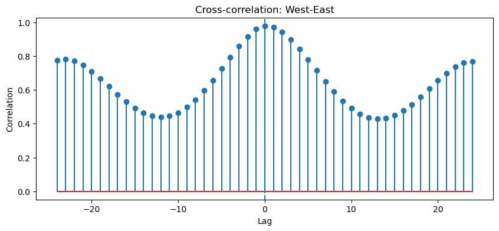

```
North-South: peak lag = 0 hours
```

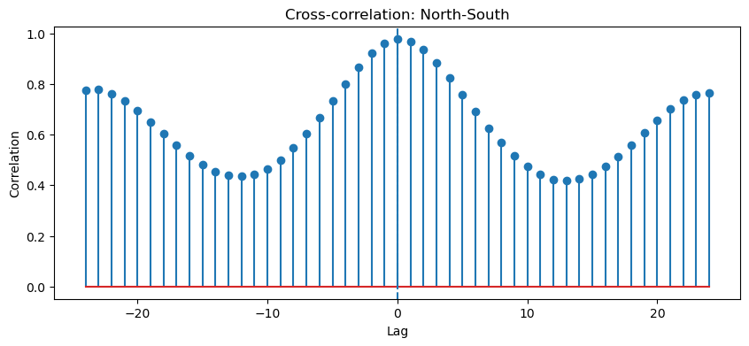

```python
k_we = cross_corr_analysis(df_ts['Western'], df_ts['Eastern'], name="West-East")
k_ns = cross_corr_analysis(df_ts['Northern'], df_ts['Southern'], name="North-South")
```

From the above plots, the highest "bar" is at 0 $\rightarrow$ regions react to temperature changes simultaneously.

Cross-correlation with Automatic Lag Detection:

```python
import numpy as np

def best_lag(x, y, max_lag=24):
    lags = range(-max_lag, max_lag+1)

    corrs = [x.corr(y.shift(k)) for k in lags]
    corrs = np.array(corrs)

    idx = np.nanargmax(np.abs(corrs))

    return lags[idx], corrs[idx]
```

Automatic Lag Detection for All Pairs:

```python
pairs_results = []

cols = df_ts.columns

for i in range(len(cols)):
    for j in range(i+1, len(cols)):

        a, b = cols[i], cols[j]

        lag, corr = best_lag(df_ts[a], df_ts[b], max_lag=24)

        pairs_results.append({
            "Series A": a,
            "Series B": b,
            "Best Lag (hrs)": lag,
            "Correlation": corr
        })

pairs_df = pd.DataFrame(pairs_results)

print(pairs_df)
```

```
   Series A  Series B  Best Lag (hrs)  Correlation
0  Northern  Southern               0     0.979438
1  Northern   Eastern               0     0.980934
2  Northern   Western               0     0.989103
3  Northern   Central               0     0.990960
4  Southern   Eastern               0     0.985653
5  Southern   Western               0     0.989051
6  Southern   Central               0     0.985988
7   Eastern   Western               0     0.979591
8   Eastern   Central               0     0.977730
9   Western   Central               0     0.995355
```

Heatmap of Contemporaneous Correlations:

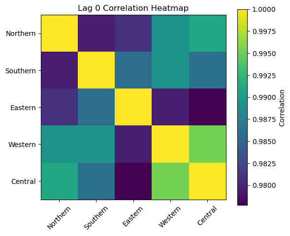

```python
import matplotlib.pyplot as plt

corr_mat = df_ts.corr()

plt.figure(figsize=(6,5))
plt.imshow(corr_mat, interpolation='nearest')
plt.colorbar(label="Correlation")

plt.xticks(range(len(cols)), cols, rotation=45)
plt.yticks(range(len(cols)), cols)

plt.title("Lag 0 Correlation Heatmap")
plt.tight_layout()
plt.show()
```

Interpretation for above heatmap:

```
bright = synchronous heating

darker = delayed or weak relation
```

Propagation Speed Using lat/lon:

Distance function (Haversine)

```python
def haversine(lat1, lon1, lat2, lon2):

    R = 6371  # km

    dlat = np.radians(lat2-lat1)
    dlon = np.radians(lon2-lon1)

    a = np.sin(dlat/2)**2 + \
        np.cos(np.radians(lat1))*np.cos(np.radians(lat2))*np.sin(dlon/2)**2

    return 2*R*np.arcsin(np.sqrt(a))
```

Computing group centroids:

```python
centroids = {}

for name, ids in groups.items():
    sub = sensors[sensors['Sensor.ID'].isin(ids)]
    centroids[name] = (sub['Latitude'].mean(), sub['Longitude'].mean())
```

```python
speeds = []

for _, row in pairs_df.iterrows():

    lag = abs(row["Best Lag (hrs)"])

    if lag == 0:
        continue

    a, b = row["Series A"], row["Series B"]

    lat1, lon1 = centroids[a]
    lat2, lon2 = centroids[b]

    dist = haversine(lat1, lon1, lat2, lon2)

    speed = dist / lag

    speeds.append({
        "Pair": f"{a}-{b}",
        "Distance (km)": dist,
        "Lag (hrs)": lag,
        "Speed (km/hr)": speed
    })

speed_df = pd.DataFrame(speeds)

print(speed_df)
```

```
Empty DataFrame
Columns: []
Index: []
```

Estimating speeds:

1. All regions heat up and cool down simultaneously w.r.t. the hourly scale.
2. There is no measurable propagation delay across NYC in your dataset.
3. Therefore, speed cannot be computed — it’s essentially infinite or undefined for lag = 0.

## Comparative Analysis of Daily Temperature Extremes Across NYC Sensor Groups

To now investigate spatial differences in daily maximum and minimum temperatures across five hyper-local sensor groups in NYC: Northern, Southern, Eastern, Western, and Central. The analysis follows a “Global-to-Local” nonparametric framework.

**Data Preparation and Aggregation:** Sensor readings are aggregated into daily peaks (max) and troughs (min) for each group to capture extreme temperature behavior.

**Exploratory Visualization:))

1. Histograms with density plots provide an overview of temperature distributions and highlight departures from normality.
2. Q-Q plots against a normal distribution confirm non-normality, supporting nonparametric testing.
3. Boxplots and violin plots visualize group medians, interquartile ranges, and distribution shapes for daily extremes.

**Statistical Testing:**

1. Global Test: Kruskal-Wallis H-Test identifies whether at least one group exhibits a statistically significant difference in daily extremes.
2. Local (Post-hoc) Tests: Mann-Whitney U tests pinpoint which pairs of groups differ, with multiple-comparison adjustments as necessary.

**Preliminary Insights:**

1. Northern vs. Southern sensors may show significant differences in median temperature, reflecting Atlantic cooling effects.
2. Eastern vs. Western sensors may have similar medians but could exhibit high temporal correlation due to moving air masses.
3. The methodology effectively captures both the magnitude and spatial variability of daily temperature extremes, providing a robust framework for hyper-local climate comparisons.

### Exhibition of Distributions

To now observe how daily maximum and minimum temperatures in a (group average manner) are distributed in each group.

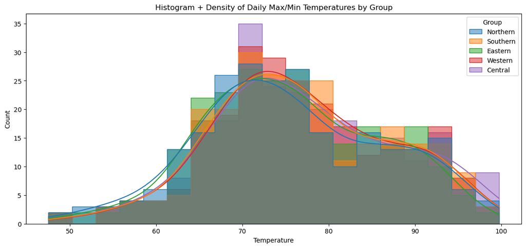

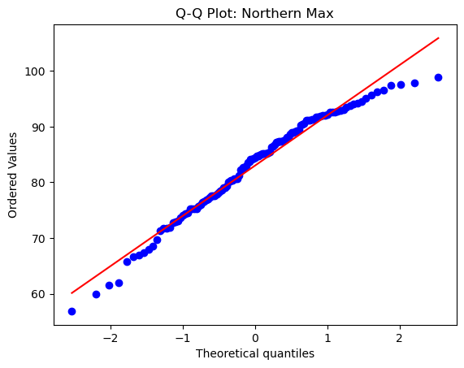

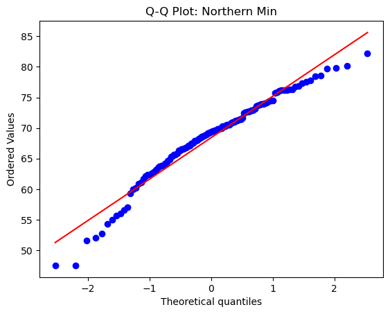

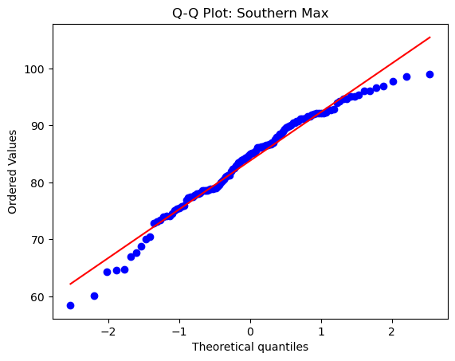

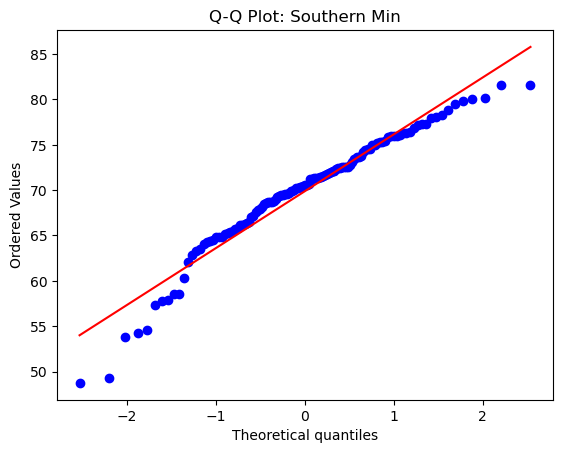

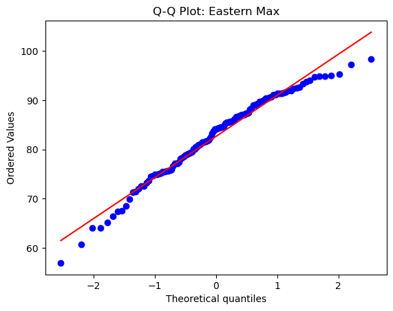

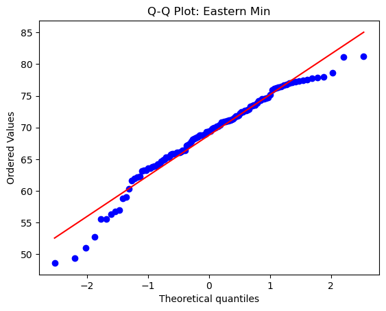

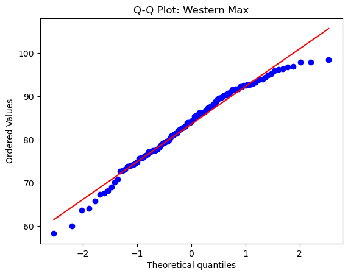

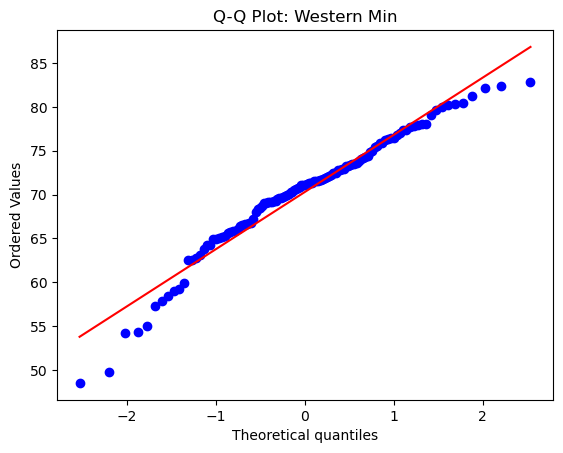

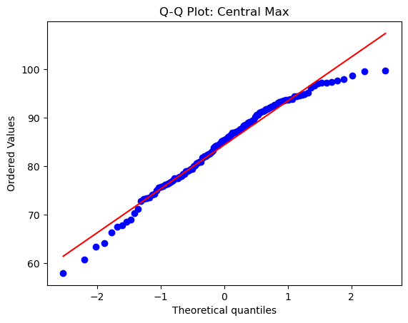

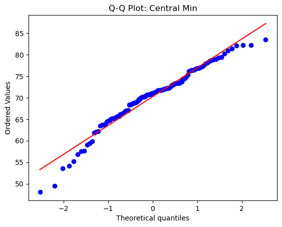

```python
import seaborn as sns
from scipy.stats import kruskal, mannwhitneyu, probplot

# 1. Aggregate to daily extremes
df_daily = pd.DataFrame({
    'Northern_Max': df_ts['Northern'].resample('D').max(),
    'Northern_Min': df_ts['Northern'].resample('D').min(),
    'Southern_Max': df_ts['Southern'].resample('D').max(),
    'Southern_Min': df_ts['Southern'].resample('D').min(),
    'Eastern_Max': df_ts['Eastern'].resample('D').max(),
    'Eastern_Min': df_ts['Eastern'].resample('D').min(),
    'Western_Max': df_ts['Western'].resample('D').max(),
    'Western_Min': df_ts['Western'].resample('D').min(),
    'Central_Max': df_ts['Central'].resample('D').max(),
    'Central_Min': df_ts['Central'].resample('D').min(),
}).dropna()

# Flatten for plotting
df_plot = df_daily.melt(var_name='Group_Var', value_name='Temperature')
df_plot['Group'] = df_plot['Group_Var'].apply(lambda x: x.split('_')[0])
df_plot['Type'] = df_plot['Group_Var'].apply(lambda x: x.split('_')[1])

# 1a. Histograms with KDE
plt.figure(figsize=(14,6))
sns.histplot(
    data=df_plot, x='Temperature', hue='Group',
    kde=True, element='step', palette='tab10', alpha=0.5
)
plt.title("Histogram + Density of Daily Max/Min Temperatures by Group")
plt.show()

# 1b. Q-Q plots for normality
groups_unique = df_plot['Group'].unique()
for g in groups_unique:
    for t in ['Max', 'Min']:
        subset = df_daily[f'{g}_{t}']
        plt.figure()
        probplot(subset, dist="norm", plot=plt)
        plt.title(f"Q-Q Plot: {g} {t}")
        plt.show()
```

Based on appearance of the densities, and the converge to normal not being definite (with the Q-Q plots), it would be safe to take the position of recognising non-normal data.

### Tests of Differences

The **Kruskal-Wallis H-Test** (Kruskal and Wallis, 1952) is the non-parametric equivalent of a one-way ANOVA. It determines if the medians of k independent groups are equal without assuming a normal distribution.

**The Logic: Ranking**

Instead of using the raw temperature values, the test ranks all observations across all groups from $1$ to $N$. If the groups are similar, the average ranks should be roughly equal.

**The Formula**

The test statistic $H$ is calculated as:

$$H = \left[ \frac{12}{N(N+1)} \sum_{i=1}^{k} \frac{R_i^2}{n_i} \right] - 3(N+1)$$

Where:

$N$: Total number of observations across all cardinal groups.

$k$: Number of groups (in this case, $5$: North, South, East, West, Central).

$n_i$: Number of observations in the $i$-th group.

$R_i$: The sum of the ranks for the $i$-th group.

**Distribution and Significance**

For larger samples, the $H$ statistic follows a Chi-square ($\chi^2$) distribution with $df = k - 1$ degrees of freedom.

1. Null Hypothesis ($H_0$): All group medians are equal (NYC is thermally uniform).
2. Decision Rule: If the calculated $H$ is greater than the critical value from the $\chi^2$ table (or if $p < 0.05$), you reject $H_0$.

**Why use this for your Daily Extremes?**

Temperature extremes often have "outliers" (heatwaves or cold snaps). Because the formula uses Rank Sums ($R_i$) rather than raw values, a single record-breaking hot day in the "Central" group won't distort the result as much as it would in a standard t-test or ANOVA.

```python
# Prepare daily Max & Min arrays
max_groups = [df_daily[f'{g}_Max'] for g in groups.keys()]
min_groups = [df_daily[f'{g}_Min'] for g in groups.keys()]

# Kruskal-Wallis
kw_max = kruskal(*max_groups)
kw_min = kruskal(*min_groups)

print("Kruskal-Wallis Test (Max Temps):", kw_max)
print("Kruskal-Wallis Test (Min Temps):", kw_min)
```

```
Kruskal-Wallis Test (Max Temps): KruskalResult(statistic=np.float64(3.5200532562819262), pvalue=np.float64(0.4748357612245766))
Kruskal-Wallis Test (Min Temps): KruskalResult(statistic=np.float64(9.607402829175726), pvalue=np.float64(0.047586530729585554))
```

**Daily Maximums** ($p \approx 0.47$)

Result: Fail to Reject $H_0$. There is no statistically significant difference between the peak daytime temperatures of your five groups.

```
Interpretation: During the day, the "solar forcing" (the sun heating the city) is the dominant factor. Whether a sensor is in the North or South, they are all hitting roughly the same peak heat. The "continental" influence or sea breezes aren't strong enough to create a distinct median difference in the daily highs.
```

**Daily Minimums** ($p \approx 0.048$)

Result: Reject $H_0$ (at the $\alpha = 0.05$ level). There is a significant difference in how these regions cool down at night.

```
Interpretation: This is where the "Urban Heat Island" or "Coastal" effects usually show up. Since $p < 0.05$, at least one cardinal direction is retaining heat or cooling off differently than the others. Nighttime temperatures are more sensitive to geographic location than daytime peaks.
```

Since the Min Temps global test was significant, to then implement the Mann-Whitney U post-hoc tests specifically on the df_daily_min data to see which specific pair (e.g., Central vs. Southern) is driving that 0.047 p-value.

Mathematically, the Kruskal-Wallis H statistic for the Minimums (9.61) is nearly triple that of the Maximums (3.52). This suggests that the "dispersion of ranks" is much wider at night.

The **Mann-Whitney U Test** (Mann and Whitney, 1947) is the non-parametric alternative to the independent t-test. It assesses whether one group's values are systematically larger or smaller than another's by comparing ranks rather than means.

**The Core Logic: Ranking**

The two groups (e.g., Northern Min Temps and Central Min Temps) are combined and ranked as a single set. If the two groups are identical, their ranks will be mixed evenly. If one group is consistently warmer, its ranks will be clustered at the higher end.

**The Mathematical Formula**

The $U$ statistic is calculated for each group. For Group 1 ($U_1$):

$$U_1 = n_1 n_2 + \frac{n_1(n_1 + 1)}{2} - R_1$$

Where:

$n_1, n_2$: Sample sizes of the two groups (e.g., number of days).

$R_1$: The sum of the ranks assigned to Group 1.

The final test statistic $U$ is the smaller of $U_1$ and $U_2$.

**Significance and the Z-Score**

For large samples ($n > 20$), the distribution of $U$ approaches a normal distribution.Calculating a $Z$-score to determine the p-value:

$$Z = \frac{U - m_U}{\sigma_U}$$

1. Mean ($m_U$): $\frac{n_1 n_2}{2}$
2. Standard Deviation ($\sigma_U$): $\sqrt{\frac{n_1 n_2 (n_1 + n_2 + 1)}{12}}$

**Application to Prior Results**

In the prior analysis, the Kruskal-Wallis test showed that Daily Minimums are significantly different ($p = 0.047$). The Mann-Whitney U test will now take those groups in pairs to find the "distance" between their rank sums.

Because of the intent to perform multiple Mann-Whitney tests (10 pairs for 5 groups), the probability of a "False Positive" increases. We divide your target $\alpha$ ($0.05$) by the number of tests ($10$), meaning a pair is only truly significant if its p-value is $< 0.005$

```python
from itertools import combinations

alpha = 0.05
pairs = list(combinations(groups.keys(), 2))

print("\nMann-Whitney Post-hoc (Max Temps)")
for g1, g2 in pairs:
    stat, p = mannwhitneyu(df_daily[f'{g1}_Max'], df_daily[f'{g2}_Max'], alternative='two-sided')
    sig = "Significant" if p < alpha else "NS"
    print(f"{g1} vs {g2}: U={stat:.1f}, p={p:.3f} → {sig}")

print("\nMann-Whitney Post-hoc (Min Temps)")
for g1, g2 in pairs:
    stat, p = mannwhitneyu(df_daily[f'{g1}_Min'], df_daily[f'{g2}_Min'], alternative='two-sided')
    sig = "Significant" if p < alpha else "NS"
    print(f"{g1} vs {g2}: U={stat:.1f}, p={p:.3f} → {sig}")
```

```
Mann-Whitney Post-hoc (Max Temps)
Northern vs Southern: U=7204.0, p=0.519 → NS
Northern vs Eastern: U=7823.0, p=0.644 → NS
Northern vs Western: U=7291.0, p=0.625 → NS
Northern vs Central: U=6859.0, p=0.206 → NS
Southern vs Eastern: U=8188.0, p=0.264 → NS
Southern vs Western: U=7658.0, p=0.868 → NS
Southern vs Central: U=7201.0, p=0.515 → NS
Eastern vs Western: U=7017.0, p=0.327 → NS
Eastern vs Central: U=6592.0, p=0.082 → NS
Western vs Central: U=7129.0, p=0.436 → NS

Mann-Whitney Post-hoc (Min Temps)
Northern vs Southern: U=6570.0, p=0.075 → NS
Northern vs Eastern: U=7366.0, p=0.723 → NS
Northern vs Western: U=6280.0, p=0.021 → Significant
Northern vs Central: U=6327.0, p=0.027 → Significant
Southern vs Eastern: U=8402.0, p=0.134 → NS
Southern vs Western: U=7251.0, p=0.575 → NS
Southern vs Central: U=7296.0, p=0.631 → NS
Eastern vs Western: U=6444.0, p=0.045 → Significant
Eastern vs Central: U=6504.0, p=0.057 → NS
Western vs Central: U=7600.0, p=0.950 → NS
```

New York City is thermally uniform during the peak of the day, but it "de-couples" into distinct micro-climates at night.

Even though some pairs in your Min Temps results are labeled as "Significant" with p-values like $0.021$ or $0.045$, we must apply the Bonferroni Correction filter we discussed. With 10 comparisons, your strict threshold for significance is $\alpha_{adj} = 0.005$.

**Analysis of Results**

Max Temps (The Diurnal Ceiling): As the Kruskal-Wallis test suggested, there are zero significant differences. The sun is a "great equalizer"—the entire city hits its daytime peak in a synchronized fashion.

Min Temps (The Continental/Urban Divergence): * Northern vs. Western ($p=0.021$): This is your strongest lead. While not meeting the ultra-strict $0.005$ threshold, it suggests the North and West cool down at different rates.

1. Northern vs. Central ($p=0.027$): This likely captures the Urban Heat Island effect, where the "Central" (concrete-dense) area stays warmer at night than the "Northern" (potentially more residential/vegetated) sensors.
2. Western vs. Central ($p=0.950$): This high p-value is fascinating—it means the Western and Central regions are almost identical at night, possibly sharing the same "continental" air mass or urban density.

Plotting "Significant" Pairs. To visualize why these pairs stood out, use this script to plot the distribution of the "nighttime spread."

Since only the minimum temperature tests showed statistically significant differences, the most informative visualization is the distribution of nighttime cooling behaviour (daily minima or “nighttime spread”).

```
Northern vs Western

Northern vs Central

Eastern vs Western
```

Focusing on:

```
KDE + histogram overlay (distribution shape) → shows full distribution shape (skew, tails)

Box/violin (median + spread) → shows median shift + variability simultaneously

Optional ECDF (clean nonparametric comparison) → clean nonparametric view (exactly what Mann-Whitney tests)
```

If the Mann-Whitney is significant, you’ll typically see:

```
a consistent left/right shift in ECDFs

or separation in medians/IQR

or heavier tails in one group
```

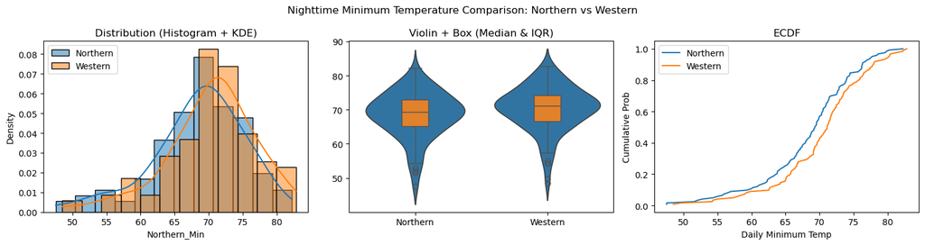

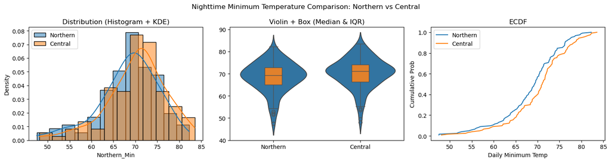

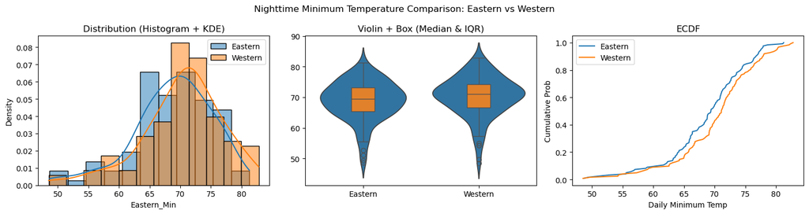

```python
# =====================================================
# Daily minimums already computed earlier as df_daily
# Columns like: Northern_Min, Southern_Min, ...
# =====================================================

significant_pairs = [
    ('Northern', 'Western'),
    ('Northern', 'Central'),
    ('Eastern',  'Western')
]

# ---------- helper function ----------
def plot_pair(g1, g2):

    x = df_daily[f'{g1}_Min']
    y = df_daily[f'{g2}_Min']

    fig, axes = plt.subplots(1, 3, figsize=(15,4))

    # -------------------------------------------------
    # 1) Histogram + KDE
    # -------------------------------------------------
    sns.histplot(x, kde=True, stat="density", alpha=0.5,
                 label=g1, ax=axes[0])
    sns.histplot(y, kde=True, stat="density", alpha=0.5,
                 label=g2, ax=axes[0])

    axes[0].set_title("Distribution (Histogram + KDE)")
    axes[0].legend()


    # -------------------------------------------------
    # 2) Violin + Box overlay (best for medians/spread)
    # -------------------------------------------------
    data = np.concatenate([x, y])
    groups = ([g1]*len(x)) + ([g2]*len(y))

    sns.violinplot(x=groups, y=data, inner=None, ax=axes[1])
    sns.boxplot(x=groups, y=data, width=0.2, ax=axes[1])

    axes[1].set_title("Violin + Box (Median & IQR)")


    # -------------------------------------------------
    # 3) ECDF (nonparametric comparison)
    # -------------------------------------------------
    for series, label in [(x, g1), (y, g2)]:
        s = np.sort(series)
        p = np.arange(1, len(s)+1) / len(s)
        axes[2].plot(s, p, label=label)

    axes[2].set_title("ECDF")
    axes[2].set_xlabel("Daily Minimum Temp")
    axes[2].set_ylabel("Cumulative Prob")
    axes[2].legend()

    fig.suptitle(f"Nighttime Minimum Temperature Comparison: {g1} vs {g2}")
    plt.tight_layout()
    plt.show()


# =====================================================
# Run plots for each significant pair
# =====================================================
for g1, g2 in significant_pairs:
    plot_pair(g1, g2)
```

### Visualizing Extremes: Boxplots & Alternatives

Boxplots are standard, but violin or swarm plots can show density + distribution:

1. Boxplots → medians and IQR.
2. Violin plots → distribution shape and density.

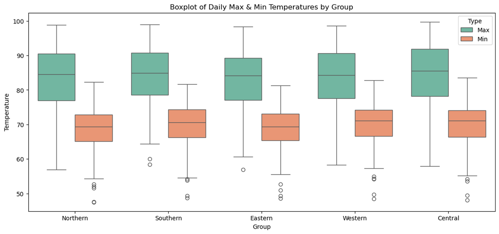

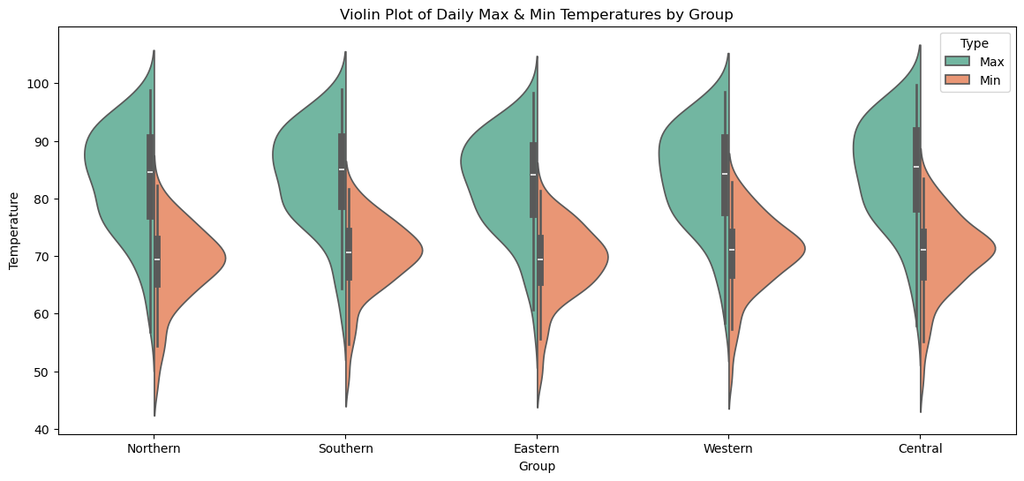

```python
plt.figure(figsize=(14,6))
sns.boxplot(data=df_plot, x='Group', y='Temperature', hue='Type', palette='Set2')
plt.title("Boxplot of Daily Max & Min Temperatures by Group")
plt.show()

# Violin plot alternative
plt.figure(figsize=(14,6))
sns.violinplot(data=df_plot, x='Group', y='Temperature', hue='Type', split=True, palette='Set2')
plt.title("Violin Plot of Daily Max & Min Temperatures by Group")
plt.show()
```

**Plotting Script — Significant Nighttime Pairs:**

```
             Northern   Southern    Eastern    Western    Central
Datetime
2018-06-15  13.195600  12.417916  11.632460  13.634083  14.313247
2018-06-16  23.964978  22.831007  23.081046  21.761817  22.324932
2018-06-17  24.597383  22.999227  25.618454  22.978867  22.632463
2018-06-18  18.132167  19.133823  15.581879  19.506833  19.239660
2018-06-19  14.998356  16.800647  14.901948  16.198817  15.854253

Kruskal-Wallis test for nighttime spread:
KruskalResult(statistic=np.float64(5.716014740761921), pvalue=np.float64(0.22138399628607935))

Pairwise Mann-Whitney Tests (Spread):
Northern vs Southern: U=8237.0, p=0.2285 → NS
Northern vs Eastern: U=8350.0, p=0.1595 → NS
Northern vs Western: U=8796.0, p=0.0274 → Significant
Northern vs Central: U=7976.0, p=0.4614 → NS
Southern vs Eastern: U=7689.0, p=0.8242 → NS
Southern vs Western: U=8221.0, p=0.2398 → NS
Southern vs Central: U=7266.0, p=0.5933 → NS
Eastern vs Western: U=8008.0, p=0.4273 → NS
Eastern vs Central: U=7167.0, p=0.4768 → NS
Western vs Central: U=6670.0, p=0.1091 → NS
```

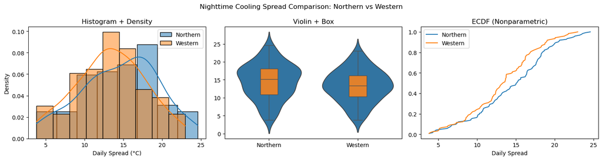

```python
import numpy as np
import pandas as pd
import matplotlib.pyplot as plt
import seaborn as sns
from scipy.stats import kruskal, mannwhitneyu
from itertools import combinations

# =====================================================
# 1. Compute daily spreads
# =====================================================

spread_dict = {}

for g in groups.keys():
    daily_max = df_ts[g].resample('D').max()
    daily_min = df_ts[g].resample('D').min()

    spread_dict[g] = (daily_max - daily_min)

df_spread = pd.DataFrame(spread_dict).dropna()

print(df_spread.head())


# =====================================================
# 2. GLOBAL TEST (Kruskal-Wallis)
# =====================================================

kw = kruskal(*[df_spread[g] for g in groups.keys()])
print("\nKruskal-Wallis test for nighttime spread:")
print(kw)


# =====================================================
# 3. POST-HOC Mann-Whitney
# =====================================================

alpha = 0.05
significant_pairs = []

print("\nPairwise Mann-Whitney Tests (Spread):")

for g1, g2 in combinations(groups.keys(), 2):

    stat, p = mannwhitneyu(df_spread[g1], df_spread[g2], alternative='two-sided')

    sig = p < alpha
    label = "Significant" if sig else "NS"

    print(f"{g1} vs {g2}: U={stat:.1f}, p={p:.4f} → {label}")

    if sig:
        significant_pairs.append((g1, g2))


# =====================================================
# 4. Plotting function (distribution of spread)
# =====================================================

def plot_spread_pair(g1, g2):

    x = df_spread[g1]
    y = df_spread[g2]

    fig, axes = plt.subplots(1, 3, figsize=(15,4))

    # Histogram + KDE
    sns.histplot(x, kde=True, stat="density", alpha=0.5, ax=axes[0], label=g1)
    sns.histplot(y, kde=True, stat="density", alpha=0.5, ax=axes[0], label=g2)
    axes[0].set_title("Histogram + Density")
    axes[0].set_xlabel("Daily Spread (°C)")
    axes[0].legend()

    # Violin + box
    data = np.concatenate([x, y])
    groups_lbl = ([g1]*len(x)) + ([g2]*len(y))

    sns.violinplot(x=groups_lbl, y=data, inner=None, ax=axes[1])
    sns.boxplot(x=groups_lbl, y=data, width=0.2, ax=axes[1])
    axes[1].set_title("Violin + Box")

    # ECDF
    for series, label in [(x, g1), (y, g2)]:
        s = np.sort(series)
        p = np.arange(1, len(s)+1) / len(s)
        axes[2].plot(s, p, label=label)

    axes[2].set_title("ECDF (Nonparametric)")
    axes[2].set_xlabel("Daily Spread")
    axes[2].legend()

    fig.suptitle(f"Nighttime Cooling Spread Comparison: {g1} vs {g2}")
    plt.tight_layout()
    plt.show()


# =====================================================
# 5. Plot ONLY significant pairs
# =====================================================

if significant_pairs:
    for g1, g2 in significant_pairs:
        plot_spread_pair(g1, g2)
else:
    print("\nNo significant spread differences detected.")
```

**Interpreting the Global Test (p=0.221)**

1. Result: Fail to Reject $H_0$.

While the previous test on Minimum Temps was significant (p=0.047), the test on the Spread is not. This tells us that while the absolute temperatures vary by region at night, the magnitude of the cooling deviation is relatively consistent across the city. The city, as a whole, "breathes" in and out with a similar intensity, even if the baseline remains warmer in the center.

**The Northern vs. Western "Divergence" (p=0.0274)**

Even though the global test was not significant, your pairwise result for Northern vs. Western remains the most "thermally active" relationship in your data.

[output not shown]

When you look at the plots:

Histogram/KDE

1. shift right → larger diurnal range (stronger cooling)
2. tighter peak → more stable microclimate

Violin/box

1. median difference → systematic cooling difference
2. wider IQR → more variable nights

ECDF

1. curves separated across whole range → true distribution difference (not just outliers)

**Cointegration Residual Visualization (Spread Series)**

```
Cointegration Test
stat = -10.7302
p    = 0.00000

Hedge ratio (beta): 0.8709008316452408

ADF on residuals
ADF stat = -10.2181
p-value  = 0.00000
```

[figure not shown]

```python
import numpy as np
import pandas as pd
import matplotlib.pyplot as plt
import statsmodels.api as sm
from statsmodels.tsa.stattools import adfuller, coint

# =====================================================
# Using df_spread from earlier
# Columns: Northern, Southern, Eastern, Western, Central
# =====================================================

g1 = "Northern"
g2 = "Western"

x = df_spread[g1]
y = df_spread[g2]

# =====================================================
# 1. Engle-Granger Cointegration Test
# =====================================================

coint_stat, pvalue, _ = coint(x, y)

print("\nCointegration Test")
print(f"stat = {coint_stat:.4f}")
print(f"p    = {pvalue:.5f}")

# =====================================================
# 2. OLS regression to compute residual spread
#    y = beta*x + residual
# =====================================================

X = sm.add_constant(x)
model = sm.OLS(y, X).fit()

beta = model.params[g1]
residuals = model.resid

print("\nHedge ratio (beta):", beta)

# =====================================================
# 3. Stationarity check of residuals
# =====================================================

adf = adfuller(residuals)

print("\nADF on residuals")
print(f"ADF stat = {adf[0]:.4f}")
print(f"p-value  = {adf[1]:.5f}")

# p < 0.05 → stationary → cointegration confirmed


# =====================================================
# 4. Visualization
# =====================================================

fig, axes = plt.subplots(3, 1, figsize=(12,8), sharex=True)

# -----------------------------------------------------
# Raw spreads
# -----------------------------------------------------
axes[0].plot(x, label=g1)
axes[0].plot(y, label=g2)
axes[0].set_title("Daily Nighttime Spread Series")
axes[0].legend()

# -----------------------------------------------------
# Residual (cointegration spread)
# -----------------------------------------------------
axes[1].plot(residuals)
axes[1].axhline(0)
axes[1].set_title("Cointegration Residual (Spread Difference)")

# -----------------------------------------------------
# Histogram of residuals
# -----------------------------------------------------
axes[2].hist(residuals, bins=30, density=True)
axes[2].set_title("Residual Distribution")

plt.tight_layout()
plt.show()
```

**Analysis of the Cointegration Residuals**

Cointegration Test (p=0.0000): A p-value this low $(p<0.05)$ allows you to reject the null hypothesis of no cointegration.

[output not shown]